EPM walkthrough

# EPM, end to end

The Enterprise Performance Model, as a course you read with the code open: the business it describes, what each part is, how it was built, how to run it, and what you should see.

Start with the business Build it yourself

## Part 1: Understand it

The tour starts with the business, then covers what each part is, how it works and why it was built that way. Each section links to the build steps in Part 2 that create it.

**Two ways through this page.**

- Read Part 1 first to understand the system, then rebuild it step by step in Part 2.
- Or start at the first build step and follow each step's "Explained in" link back here when you want the why.
- Every file is named by its full path from the repository root, so you can open it beside this page.

## The business, and how it is mapped

This work began with a business problem. The downstream business had rebuilt its reports and lost track of what the numbers mean.

To say what a number means, you must first say which process produces it, in which value stream, and who answers for it. So the Enterprise Performance Model starts from the business architecture, and the ontology comes later, as the checked form of that architecture.

The master index, `EPM-FOUND-000.md`, sets the chain below. Read forward, it is a design sequence. Read backward, it is an audit: take a number on a dashboard and trace it to a business goal someone owns.

"The Tableau-to-Power BI migration moved the pictures but not the meaning. Every report was rebuilt, but nobody recorded what each number means, who owns it, what good looks like, or where it comes from."

`EPM-FOUND-000.md`, "Executive orientation"

1. Strategy and objectives
2. Business domains
3. Value streams and stages
4. Capabilities
5. Business processes
6. Activities
7. Decisions
8. Measurements and metrics
9. KPIs and outcomes
10. Data products
11. KPI Store, semantic views, APIs
12. Reports, analytics, AI

The primary architecture chain, shortened from `EPM-FOUND-000.md`. The blue links are this section's subject. In the document's words, "Wherever the trace breaks is the gap this project closes."

### The process map: what the business does

`business_architecture/business_process/downstream_process_map.json` is the process authority (`AGENTS.md`, "Working rules"). It is one tree with two roots. Downstream Operations holds Commercial & Marketing, Refining and Midstream. Enabling Functions holds Supply Chain, Finance, Shared Services, Process Excellence & IT, Human Resources, Legal & Corporate Communications, and EHS & Government Reporting.

It holds 707 nodes today, and held 680 when the build started. Each node has a level from L0 to L6, an ID where one is assigned, a name and its children.

### Most of the map is at L5

L0**2**

L1**10**

L2**13**

L3**48**

L4**137**

L5**474**

L6**23**

### The value streams: how the work creates value

The map says what exists. A value stream says what runs from a trigger to an outcome, and it crosses the map's branches. There are two. Each stage holds processes, and each of those processes links to nodes in the map through `linkedProcessIds`.

#### Commercial Hydrocarbon Lifecycle: 12 processes in 3 stages

**Starts with:** Market/supply opportunity informed by strategic supply & demand plan. **Ends with:** Profitable placement of crude/products with controlled risk, settled transactions, and learnings fed back to planning. Settlement loops back to market intelligence.

#### Market & Strategy Formation

1. - Market Intelligence & Planning
   - Market Price Calculation & Validation
   - Supply & Procurement Strategy
   - Deal Negotiation & Capture

#### Execution & Operations

2. - Logistics Planning & Scheduling
   - Terminal & Transport Operations
   - Quality Assessment & Blending Ops
   - Rack Price Setting
   - Retail Sales & Payment

#### Risk, Performance, and Control

3. - Risk Management and Position Monitoring
   - Performance Tracking & Analysis
   - Settlement and Post-Trade Reconciliation

#### Order to Cash: 46 processes in 9 stages

**Starts with:** Customer quote request / order. **Ends with:** Cash collected, disputes resolved, revenue recognized, AR sub-ledger closed. Dispute root-cause analysis feeds back into commercial policy.

#### Master Data Mgmt.

1. - Maintain Customer Master
   - Maintain Price & Discount Master
   - Maintain Product Master
   - Maintain Tax Master
   - Maintain Workflows

#### Quote & Sale

2. - Maintain Commercial Policies
   - Establish Commercial Terms & Contracts
   - Define Financing & Payment Methods
   - Issue Quotes & Renewals
   - Develop & Monitor Revenue Plan
   - Analyze Customer Profitability

#### Credit & Risk

3. - Maintain Credit Policies
   - Establish Credit Limit & Risk Code
   - Monitor Credit Against Limit
   - Review Credit Limit & Risk Code
   - Analyze Portfolio Credit Risk
   - Perform Customer Closure and Reinstatement

#### Order & Fulfilment

4. - Capture & Validate Order
   - Allocate & Release Order
   - Track & Forecast Order
   - Change / Cancel Order
   - Manage Fulfillment
   - Manage Returns

#### Billing

5. - Create & Distribute Bill
   - Perform Accounting for Self-Billing
   - Determine Taxability & Record Tax Liabilities
   - Create Exception Invoice

#### Receipt

6. - Receive Payments
   - Receive Remittance Advice
   - Apply Receipts
   - Manage Unapplied Receipts
   - Perform Reconciliations & Settlements

#### Collection

7. - Establish Collection Targets
   - Analyze AR Aging
   - Execute Collections
   - Negotiate Settlements
   - Initiate Legal Action

#### Dispute

8. - Validate Deductions
   - Receive & Validate Queries
   - Create Credit Memo / Charge Back
   - Perform Appeasements
   - Develop Root Cause Analysis & Action Plan

#### Close

9. - Perform Revenue Accounting
   - Process Bad Debt
   - Close AR Sub Ledger
   - Reconcile Indirect Tax

### Lanes and data products: who works it, and what it yields

### Office lanes

`office_lanes.json` sorts work into four lanes: front office (market-facing), middle office (control and risk), back office (completing the trade) and operations (the physical supply chain).

### Data-product portfolio

`data_product_portfolio.json` lists 49 portfolios in 19 product lines, across the Commercial, Midstream and Corporate segments. These are the data the processes produce and use.

**Built in Part 2:** step 1.

## What was missing, and how it was filled

The first map was deep in one branch and empty in the others, and most of it had no definitions. Five separate checks found the gaps. Most are filled, and the rest are on record, as open or deferred.

### The map at the start

The map first entered the repository on 2026-08-19. Of its 680 nodes, 177 had a description. Commercial & Marketing held nearly everything. Refining and Midstream had no children and no IDs, and the seven enabling functions were empty.

### How a gap was found

- **The value streams' own lists.** Each value-stream file ends with a `gapAnalysis`: stream processes the map lacks or collapses.
- **APQC.** `business_architecture/ontology/apqc-crosscheck-report.md` compared the map with APQC's process framework for downstream petroleum and named seven candidates to review. APQC is a consistency reference and never the process authority.
- **The definition queue.** Building the taxonomy showed 503 concepts with no definition (worklog, Step 3).
- **Marathon Petroleum's public filings.** `business_architecture/reference/mpc/process-map-suggestions.md` compared the map with what MPC reports.
- **The decision owner's inputs.** The customer lifecycle went into proposal MPC-P10. The customer files themselves stay out of the repository.

| Branch | Nodes, 2026-08-19 | Nodes today |
| --- | --- | --- |
| Commercial & Marketing | 669 | 633 |
| Refining | 1 | 49 |
| Midstream | 1 | 14 |
| Finance | 1 | 3 |
| Human Resources | 1 | 1 |
| EHS & Gov Reporting | 1 | 1 |
| Supply Chain Mgmt. | 1 | 1 |
| Shared Services | 1 | 1 |
| Process Excellence & IT | 1 | 1 |
| Legal & Corp Comm | 1 | 1 |

### Each gap, and where it stands

| What was missing | Found by | What was done | State |
| --- | --- | --- | --- |
| What each process means: 503 of 680 concepts had no definition | Step 3 of the build | 42 reviewed batches with the decision owner. Step 3c closed with 498 of 503 approved, and 675 of 680 concepts defined. | **Filled**; one intentional hold |
| Midstream: no processes | MPC-P01 | `MS 1` and 13 nodes for pipeline, terminal, marine and storage services. Scope: fuels logistics supporting Refining and Marketing | **Filled** for that scope |
| Refining: no IDs, planning steps only, and no home for turnarounds | MPC-P02, APQC 10.x | `RF 1`, `RF 1.1`, `RF 1.2`, turnaround coordination in `RF 1.2.1` to `RF 1.2.5`, and 42 concepts moved under Refining (R1, #108) | **Filled**; physical maintenance stays out of scope |
| Inter-refinery transfers: loss and gain, and the quality of transferred intermediates | MPC-P03's coverage check | `CM 1.1.3.7.13` Reconcile Movement Losses and Gains; `CM 1.2.5.1` widened (EPM-DEC-001-0048, 0051) | **Filled** |
| Loss Control: a data product with no owning process | Commercial stream's gap list | `CM 1.1.3.7.13` now produces it | **Partly filled**; the gap list still says it is not linked to a stage |
| Renewables: feedstock traceability | MPC-P04 | Sourcing and marketing fit existing processes. One step added: `CM 1.2.5.1.5` | **Filled**; production is parked |
| Environmental credits beyond RINs, and the 45Z tax credit | MPC-P05 | `CM 1.2.4.3.8`, with credits and the tax credit as separate lifecycles | **Filled** |
| Customer lifecycle: onboarding for every customer, an unlinked credit review, no customer master data product | The decision owner's inputs, MPC-P10 | `CM 1.3.7.1.7` Coordinate Customer Onboarding; the review linked to `CM 1.3.7.4.2`; a Customer Master data product (EPM-DEC-001-0087) | **Filled** |
| Customer processes named no systems; 25 processes shared seven names | MPC-P11, MPC-P12 | 12 processes name their systems, in 21 links. Each of the 25 now names its parent's subject (EPM-DEC-001-0103, 0105) | **Filled** |
| Order to Cash detail: collection and dispute steps collapse into one process, and Close AR Sub Ledger has no named process | O2C gap list | Recorded with the closest process for each | **Recorded**, not changed |
| Data products for customer credit and receivables; retail transaction depth; blending operations | Both gap lists | Recorded with the closest process for each | **Open** |
| Product recalls and regulatory audits, human capital, data and analytics governance, remediation | APQC, ruled in scope on 2026-09-17 | No process in the map. The decision owner deferred them on 2026-10-31, and bringing one in takes a new decision | **Deferred** (#454) |
| Fixed-asset project accounting; government, board and public relations | APQC | Boundary notes: nothing in the ontology depends on them | **Out of scope** |

Sources: `value_stream_*.json`, `apqc-scope-decisions.md`, `process-map-suggestions.md`, `proposals/MPC-P*.md`, and the worklog, compared with the map on `main` at `daf60fee`.

### How a gap gets filled

Nobody edits the map to fix a gap on sight. A proposal states the gap, gives options and recommends one. The decision owner rules, and the ruling is recorded with their words. A pull request then changes the map, and a later `core` release carries the change, because each release builds from a pinned commit of the map.

1. 2026-08-19: gap list says "Review Credit Limit & Risk Code" has no process
2. 2026-10-21: proposal MPC-P10.2 recommends a link
3. 2026-10-23: the decision owner chooses A (EPM-DEC-001-0087)
4. `value-stream` 1.1.0 carries the link

One gap from finding to release. From `business_architecture/business_process/proposals/MPC-P10-customer-lifecycle.md`.

## From the process map to the ontology

The ontology's first steps were business steps: decide what questions it must answer, keep the map's identities, and write down what each process means.

### The order of the first steps

| Date | What happened |
| --- | --- |
| 2026-09-17 | Step 0 and Step 8: APQC cross-check and the seven scope rulings, done first because scope shapes the foundations |
| 2026-09-18 | Step 1: 44 competency questions, later the regression tests. Step 2: the map's IDs kept as notations. Step 3: a SKOS taxonomy of the 680 nodes |
| 2026-09-18 to 09-21 | Step 3c: the definitions, in 42 reviewed batches |
| 2026-09-22 | Step 3d: tree changes and naming, closed with one intentional hold |
| 2026-09-30 | Step 4: the links between processes, through the evidence gate |

### The definition workbook became the ontology

| Workbook field | In the ontology |
| --- | --- |
| `name` | `skos:prefLabel` |
| `definition` | `skos:definition` |
| `scope_note` | `skos:scopeNote`: boundaries and who decides |
| `in_scope`, `out_of_scope` | Boundary assertions |
| `related_concepts` | Typed links between processes |
| `reference_sources` | Provenance, by register ID |

The review also produced 18 named rules that govern the definitions. The Billing Integrity Rule, for one, says every correction is a controlled successor document, and nothing is edited in place. `business_architecture/ontology/business-process-architecture-playbook.md` records the whole method, with each rule citing the batch that locked it. "How the ontology was built" below takes the story from here.

**Built in Part 2:** steps 1, 2, 3, 4.

## What this does not do

Read this before you form expectations. The ontology defines the business; it does not run it.

### The ontology

- **It calculates nothing.** It defines what a measure means. Values stay in the business systems and the KPI Store.
- **It holds no records.** Customers, invoices and transactions stay in their systems ("define, don't record").
- **It runs no process and replaces no system.** It does not replace the ERP, the KPI Store or Genie.
- **The business has not signed it off.** `OPEN-ITEMS.md` lists what the business still needs to answer, including who owns each concept's meaning.
- **It does not cover the whole company.** Most enabling functions have no processes, and four areas are deferred.
- **Its IRIs do not resolve.** They identify terms; nothing is hosted at those addresses.

### The pricing demo

- **Much of its data is synthetic.** Every row is labelled real, spot-anchored or synthesized, and the ten decisions and their outcomes are made up. Nothing in it is advice.
- **It did not reach its target.** The latest run passes 2 of 21 use cases, and the best on three attempts passes 3.
- **It runs on Databricks Free Edition.** It says nothing about performance at scale, and the daily limit stops long runs.

### The stores

- **They do not keep themselves in step with Git.** "The in-sync strategy" below says what runs today and what is planned.

## The big picture and a reading order

One ontology describes the downstream business: its processes, who does them, the measures, systems, data products and market series. Everything else in the repository either builds it, checks it, copies it into a store, or uses it.

The Turtle files in git are the master copy. Neo4j, AuraDB and the Databricks table `epm_triples` are projections that can be rebuilt from them at any time (`business_architecture/ontology/projection/pipeline.py`, its docstring). The pricing demo in `demos/downstream-pricing-databricks-free/` is the proof of use: a Databricks workspace whose agents read each measure's definition from the ontology before answering.

[figure not shown]

The whole system. Ports and names from `LOCAL-STORES.md`; the demo's layers from the demo `README.md`, "The pipeline".

[figure not shown]

The repository's own `epm-ontology-guide.html`, step 3 of the reading order.

### A reading order that works

1. `README.md` at the repository root, then `AGENTS.md` (how every change is made and reviewed).
2. `business_architecture/ontology/README.md` and `MODULES.md`: what the modules are and how they connect.
3. `business_architecture/ontology/epm-ontology-guide.html` in a browser: the crack-spread measure traced through every module.
4. `business_architecture/ontology/business-process-architecture-playbook.md`: how the process definitions were decided.
5. `business_architecture/ontology/OPEN-ITEMS.md`: what is still open, and what we need from the business.
6. One module end to end: `business_architecture/ontology/kpi/` (its CSV tables, `build_measures.py`, `measures.ttl`, `shapes.ttl`, `test_measures.py`), then its release in `releases/kpi/1.3.0/`.
7. `scripts/check.sh` and `scripts/epm_facts.py`: how the repository checks itself.
8. `business_architecture/ontology/projection/`: `README.md`, `pipeline.py`, `LOCAL-STORES.md`, `sync_stores.py`, and the runbook `ontology-stores-runbook.html`.
9. `demos/downstream-pricing-databricks-free/README.md` and `DATA.md`, then the code in the order of "Run it" ("The pricing demo, file by file" below).
10. The decision records in `business_architecture/domain/decisions/` when you want to know why something is the way it is.

### Which document answers which question

Each document has one job. This page tells the story end to end and points to the others for depth.

| Your question | Read | Its job |
| --- | --- | --- |
| What did we build, and how, end to end? | This walkthrough | The story, from the business to the demo, and the steps to rebuild it |
| How were the process definitions decided? | `business_architecture/ontology/business-process-architecture-playbook.md` | The review method, the batches and the 18 rules |
| How do you build an ontology, for any domain? | The `ontology` skill's guide: `skills/data/ontology/references/playbook.md` in personal-agent-skills | The company-neutral build method: twelve gated steps, with the projection as Step 12 |
| How do you project an ontology into a graph store with nothing lost? | The `ontology-to-lpg` skill's playbook: `skills/data/ontology-to-lpg/references/ontology-to-neo4j-playbook.html` in personal-agent-skills | The company-neutral projection method |
| What did this build do at each step, and when? | `business_architecture/ontology/step4/playbook/ontology-worklog.md` | The record, with the date of each step |
| What is still open on the ontology, and what do we need from the business? | `business_architecture/ontology/OPEN-ITEMS.md` | Every open item, with who answers it and its record |
| What must the ontology be able to answer? | `business_architecture/ontology/competency-questions.md`, and the guide's list with each status | The 55 questions, the acceptance test (44 until 2026-11-02, then 50 until the logical-model module's five were added the same day) |
| What does the finished ontology hold, and why these modules? | `business_architecture/ontology/epm-ontology-guide.html`, then `MODULES.md` | The result, with one measure traced through every module |
| How do I load it into a store and query it? | `business_architecture/ontology/projection/ontology-stores-runbook.html` | The running instructions |
| How do I change the ontology, or add a module? | This walkthrough, "How to change the ontology" | The steps for this ontology; the skills hold the method |
| Why is something the way it is? | `business_architecture/domain/decisions/` | The decision records, with the decision owner's words |
| What is still open on the demo? | The GitHub issues | Each failing use case and its fixes |

## How the ontology was built, from zero to done

It picked up from the process map and ended as 50 versioned, checked releases (51 since technical-graph 1.0.0, 2026-11-02). The method came from a gated, twelve-step guide; every choice that mattered was written down as a decision record.

### The starting point

**The source of truth** is `business_architecture/business_process/downstream_process_map.json`: 680 nodes when the build started and 707 today, levels L0 to L6 (`step4/playbook/ontology-worklog.md`, §1 "What we are building"; the first sections of this page describe the map). Beside it sit the value streams, the office lanes and the data-product portfolio (`value_stream_*.json`, `office_lanes.json`, `data_product_portfolio.json`) and their schemas in `business_architecture/schema/`.

**The consistency reference** is APQC's Process Classification Framework for Downstream Petroleum, v7.2.2: every local process is checked against it, and a deliberate divergence is recorded as a boundary note (worklog §1). The foundation documents start at `EPM-FOUND-000.md`, the master index.

### The end state it aimed for

"A standards-based ontology (RDF) published as a versioned DCAT catalog: a SKOS taxonomy of the process hierarchy, process definitions separated from executions, explicit RACI responsibility assignments, system and data-product linkages, SHACL validation shapes, and SPARQL regression tests derived from the competency questions." (worklog §1)

And its non-goals: it defines what things are; it does not calculate KPIs, execute processes, or replace the ERP, the KPI store or Genie.

### The method: twelve gated steps

The method is the `ontology` skill's guide, `skills/data/ontology/references/playbook.md` in personal-agent-skills. It lived in this repository until 2026-10-25, when it moved into the skill (EPM-DEC-001-0101). The worklog (`business_architecture/ontology/step4/playbook/ontology-worklog.md`, §2 "The plan") records how this build walked the steps.

| Step | What it does (skill guide) | Done in this build (worklog §2) |
| --- | --- | --- |
| 0 | Align the reference framework and survey existing ontologies | 2026-09-17 |
| 1 | Foundations: competency questions; URI, language, version, licence, module policies | 2026-09-18 |
| 2 | Identity normalization: keep the map's IDs as notations | 2026-09-18 |
| 3 | SKOS taxonomy: one concept scheme, broader/narrower, labels, definitions | 2026-09-18 |
| 4 | The relationship layer: the approved links between processes, through the evidence gate | promoted 2026-09-30 |
| 5 | Organizations, roles and responsibilities (ORG, RACI, `ref-mpc`) | 2026-10-22 (EPM-DEC-001-0083) |
| 6 | Interfaces and provenance (PROV-O, definition versus run) | 2026-10-22 |
| 7 | Cross-model integration: KPIs, data products, value streams, systems, lanes, market data | 2026-10-22 |
| 8 | Scope review against APQC, done early | 2026-09-17 |
| 9 | SHACL validation | 2026-10-22 (EPM-DEC-001-0081) |
| 10 | Publication as DCAT | 2026-10-22 |
| 11 | SPARQL regression tests from the competency questions | 2026-10-22: 43 answerable, 1 waiting, later parked |
| 12 | Property-graph projection | 2026-10-22 |

Step 4 is where the evidence discipline lives. Every proposed link between two processes is a row in a ledger, and an evidence gate (`business_architecture/ontology/step4/evidence-gate.py`) decides which rows emit a triple. Today `python3 scripts/epm_facts.py counts` prints the ledger as `824 emitting / 462 held / 12 deferred / 1 external governance / 2 structured flow / 17 scoped sequence = 1318`, and 640 canonical facts. An emitted link appears twice in `core`: as a direct triple and as a canonical-fact node that carries its evidence row (`MODULES.md`, "core").

[figure not shown]

All dates from the worklog's plan table and the decision records named in the table below (2026).

### The decisions that shaped it

| Record | Date | What it settled |
| --- | --- | --- |
| EPM-DEC-001-0005 | 2026-10-05 | What the ontology holds: concepts and public reference facts, no records of what happened ("define, don't record") |
| EPM-DEC-001-0014 | 2026-10-05 | Build a small SHACL slice before the release; the Step 9 order |
| EPM-DEC-001-0015 | 2026-10-05 | Classes plus public reference instances, with company facts in a separate module (`ref-mpc`) |
| EPM-DEC-001-0020 | 2026-10-05 | Adopt the ontology-to-LPG guideline for Step 12, with qualified-relation nodes and no reifiers |
| EPM-DEC-001-0022 | 2026-10-05 | A company-neutral ontology skill in personal-agent-skills |
| EPM-DEC-001-0023 | 2026-10-05 | Public ontologies: map to them, do not import them |
| EPM-DEC-001-0024 | 2026-10-05 | The playbook is a method; project decisions live in EPM-DEC-001 records |
| EPM-DEC-001-0026 | 2026-10-12 | A scoped sequence relation in `core`, before 1.0.0 |
| EPM-DEC-001-0028 | 2026-10-12 | Claude decides the open questions on the decision owner's behalf, from evidence, in a set order (this repo, MPC, refining peers, general sources); major releases and named items stay with the decision… |
| EPM-DEC-001-0029 | 2026-10-13 | How `core` 1.0.0 is built: targets, provenance, IRIs and the release package |
| EPM-DEC-001-0034 | 2026-10-13 | A run links to the process definition it followed through `prov:hadPlan` |
| EPM-DEC-001-0036 | 2026-10-19 | The property-graph projection pipeline (Step 12) |
| EPM-DEC-001-0042 | 2026-10-19 | Most planner measures are operational metrics; a KPI is a designation with a target and an owner |
| EPM-DEC-001-0049 | 2026-10-19 | The decision owner is named by role, never by person |
| EPM-DEC-001-0058, 0059 | 2026-10-19 | Placement kinds (only the producing process certifies) and source authority (five evidence tiers; the best wins) |
| EPM-DEC-001-0085 | 2026-10-21 | The open-ontologies trial: not adopted; it found no defect the checks miss |
| EPM-DEC-001-0095 | 2026-10-23 | The projection guideline moves into the `ontology-to-lpg` skill |
| EPM-DEC-001-0096 | 2026-10-23 | The ontology is closed |
| EPM-DEC-001-0098 | 2026-10-25 | Dispositions for the qSKOS findings on the released modules |
| EPM-DEC-001-0101 | 2026-10-25 | The playbook moves into the ontology skill as its guide |
| EPM-DEC-001-0102 | 2026-10-25 | The synthetic pricing demo in Databricks Free Edition: real public data first, labelled rows |
| EPM-DEC-001-0107 | 2026-10-26 | The ontology is done; the open points are the business's |
| EPM-DEC-001-0109 | 2026-10-28 | Databricks and the ontology: KPI and OPM identifiers, metric views by fact grain, Genie agents, agents read the ontology through definitions views |

### The standards it reused, and what it kept out

The worklog's §5 "Standards and why we chose them" lists the stack: **RDF** (the grammar), **SKOS** (the taxonomy backbone), **Dublin Core Terms** (describing sources), **RDFS/OWL** (the schema layer, used sparingly), **PROV-O** (what happened and who vouches for it), the W3C **ORG** ontology (roles for RACI), **SHACL** (the checking layer) and **DCAT** (publishing).

You can see them in the release prefixes: `organization` uses `org:`, `data-product` uses `prov:` and `dcat:`, `party` uses `foaf:` and maps product values to the Open Energy Ontology (`oeo:`). No release uses `owl:imports` (`core` 2.4.0 has none).

### Considered and kept out

EPM-DEC-001-0023 found no public business-architecture ontology for downstream oil and gas. Upstream and plant ontologies (OSDU, O3PO, ISO 15926, IDO) did not fit. GLEIF Level 2, PIDX, the Open Energy Ontology, IOF Supply Chain and FIBO each cover a piece, so EPM keeps its own terms and maps with `skos:exactMatch` and `skos:closeMatch` where they fit; IOF Supply Chain is parked. The worklog also set aside W3C SIOC and the ODPS family.

### The tools

| Tool | What it did here | Where to see it |
| --- | --- | --- |
| rdflib, pySHACL | Build, parse, query and validate every module | `scripts/check.sh` (`with_deps`), each `build_*.py` |
| ROBOT 1.9.10 with ELK | Reasoning before the projection | the driver's `project` step; `~/epm-lpg/robot.jar` |
| qSKOS checks | Label and scheme quality on the releases | EPM-DEC-001-0098, 0106 |
| Neo4j 2025.06.2 with n10s and APOC | The property-graph projection | the skill's `docker/compose.yaml` |
| Apache Jena Fuseki 6.2.0 | The standing triple store, and the round trips and walk comparisons in the driver | the `ontology-to-lpg` and `rdf-store` skills |
| Databricks (Delta, Unity Catalog, Genie) | `epm_triples` and the pricing demo | `skill-run/epm-run.json`, the demo |
| SPARQL Anything 1.3.0 | The technical graph and decision trail from the demo's own files | `demos/.../sparql/*.rq` |
| Parallel Decisions API | Outside events for the demo | `pricing_demo/outside.py` |
| `check.sh`, `epm_facts.py`, GitHub PRs and CI | Every change checked before and after push | `.github/workflows/checks.yml` |

### The agent skills and the review loop

`AGENTS.md` names the skills every agent loads: `clear-writing` for anything a person reads and `way-of-working` for any change. The build itself followed the `ontology` skill (the method above) and the `ontology-to-lpg` skill (the projection driver, which uses the `rdf-store` skill for Jena and Databricks). Every change went through a pull request: the checks before push, an independent review by a different model, and a PR verdict from the Cursor bot, with a merge only on MERGE for the current head (`AGENTS.md`, "Working rules" and "Before every push").

**Built in Part 2:** steps 1, 2, 3, 4, 5, 6, 11, 22, 26.

## Set up to run things yourself

You need Docker, uv, Python 3.12 or later, Java (11 or later for ROBOT; the technical graph ran on Java 24), and access to the Databricks Free Edition workspace and the AuraDB instance.

| Store | Where | Start or refresh it | Login file (never printed) |
| --- | --- | --- | --- |
| Local Neo4j | Bolt `localhost:17711` | the skill driver, `run_projection.py --config .../skill-run/epm-run.json` | `~/lpg-out/epm-rebuild/neo4j-run/run.env` |
| Jena | `http://127.0.0.1:13031/ds`, container `epm-jena-fuseki-1` | the driver's `jena` step, which leaves it running | none |
| Neo4j AuraDB | Neo4j's cloud | the driver's copy step | `~/.config/neo4j/aura.env` |
| Databricks `epm_triples` | `workspace.epm_ontology.epm_triples` | the driver's `databricks` step | `~/.config/databricks/epm.env` |
| Postgres, local | `127.0.0.1:55432`, container `pricing-demo-sources` | `docker compose -f docker/docker-compose.yml up -d` in the demo folder | the local demo login in `docker/docker-compose.yml` |
| Postgres, exe.dev VM | `databases.exe.xyz`, through a tunnel to `127.0.0.1:5433` | `ssh -N -L 127.0.0.1:5433:127.0.0.1:5432 databases.exe.xyz` | the demo's `.env` (`SOURCE_PG_DSN`) |
| Databricks `idp_sbx` | the demo catalog | the demo's `replicate`, `databricks`, `genie` and `tech_graph` commands | `~/.config/databricks/epm.env` or the demo's `.env` |

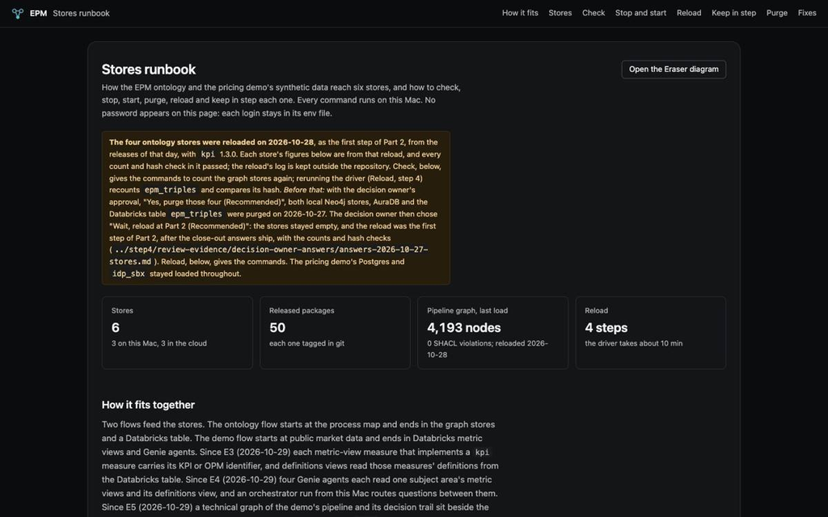

`ontology-stores-runbook.html`, the page to keep open while you start and check stores.

All of this comes from `business_architecture/ontology/projection/LOCAL-STORES.md` and the demo `README.md`. The runbook, `ontology-stores-runbook.html`, gives the commands to check, stop, start, restart after a reboot, purge, reload and keep each store in step; open it beside this page.

## The ontology, module by module

`core` is the process map. Most modules add one kind of thing and link it to core's processes; `market-data` links to `kpi`, `ref-mpc` holds the company facts, `integration` holds rules about the other modules' links, and `technical-graph` links what is built on a data platform to `data-product`, `kpi` and `system` (`MODULES.md`).

[figure not shown]

Newest release of each module, from `releases/catalog.ttl`, as of 2026-10-31; `technical-graph`, released 2026-11-02, is not drawn (the guide's module map shows it). Arrows follow the links `MODULES.md` quotes; for what each release requires, run `uv run --with rdflib python scripts/epm_facts.py modules`.

Every module folder but `technical-graph` has the same shape: CSV tables (the data the decision owner or the sources gave), a `build_*.py` that turns them into Turtle, a `vocabulary.ttl` for its terms, a `shapes.ttl` for its SHACL shapes, and a `test_*.py`. Its released packages are in `business_architecture/ontology/releases/<module>/<version>/`. Three source folders ship together as `integration` (`placement/`, `authority/`, `consumer/`), and `population/` ships in `kpi`. `technical-graph/` releases only its vocabulary and shapes; beside them, `build_example.py` cuts an example graph from the demo's technical graph as test data, and `test_technical_graph.py` tests them.

| Module | What it holds | Read first | Links |
| --- | --- | --- | --- |
| `core` | Processes as `skos:Concept`s with notation, definition and parent; approved links twice, as triples and canonical-fact nodes with evidence | `release/build_core_2_4.py`, `release/build_core.py` | the hub |
| `organization` | Roles (positions, never people), RACI assignments as nodes, the control relationship | `organization/build_roles.py`, `build_assignments.py`, `role-register.csv` | `forProcess` to core |
| `party` | The customer model, customer systems and data flows, the customer lifecycle | `party/build_party.py`, `lifecycle.csv` | `stageProcess` to core |
| `kpi` | What each measure means (never its value), classified by kind, with identifiers since 1.3.0 | `kpi/build_measures.py`, `measure-details.csv`, `measure-identifiers.csv` | `informsProcess` to core |
| `data-product` | Segments, product lines, data products; the pricing tables and lineage | `data-product/build_data_products.py`, `build_pricing.py` | `producedBy`, `consumedBy` |
| `value-stream` | Two value streams as an overlay of steps that realize core processes | `value-stream/build_value_streams.py` | `realizes`, `produces`, measure links |
| `system` | Applications, office tools and working documents the map names | `system/build_systems.py`, `systems.csv` | `supports` |
| `lane` | The four office lanes and the processes the map places in them | `lane/build_lanes.py` | `officeLane` from core |
| `market-data` | Recipes of market series (legs and region), never prices | `market-data/build_market_data.py`, `series.csv` | `seriesOf` to kpi |
| `ref-mpc` | The only company-specific module: MPC, MPLX, control, segments, refineries, brands | `ref-mpc/ref-mpc.ttl` | uses organization and party terms |
| `integration` | Rules: placement kinds, source tiers, consumer rules | `placement/`, `authority/build_source_tiers.py`, `consumer/` | over the others' links |
| `technical-graph` | The vocabulary of what was built on a data platform: hosts, source databases, tables, views, metric views, pipeline steps, quality checks and agents; definitions only, never the built records | `technical-graph/vocabulary.ttl`; its example graph, test data, from `build_example.py` | `designedAs` to data-product, `implements` to kpi, `standsFor` to system |

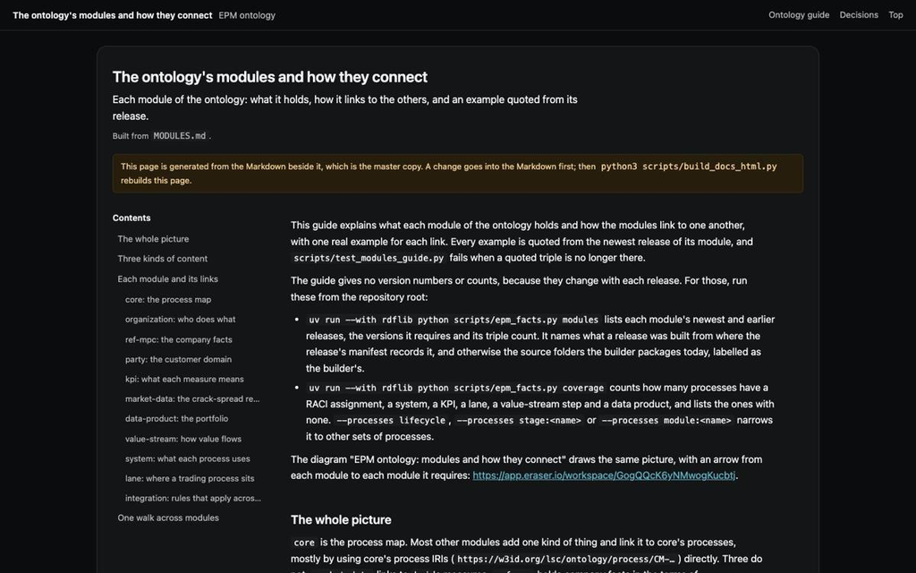

`business_architecture/ontology/MODULES.html`, the module guide these examples are quoted from.

### Real statements from the releases

These are quoted from `MODULES.md`, whose test (`scripts/test_modules_guide.py`) fails if a quoted triple leaves its release. Read each, then find it in the module's Turtle.

**core**: a process and a canonical fact

```
proc:CM-1-3-7-1-7 a skos:Concept ;
    skos:prefLabel "Coordinate Customer Onboarding"@en ;
    skos:notation "CM 1.3.7.1.7" ;
    skos:broader proc:CM-1-3-7-1 .

fact:CM-1-3-7-1-1--informedBy--CM-1-3-7-4-6
    a core:CanonicalFact ;
    core:factSubject proc:CM-1-3-7-1-1 ;
    core:factPredicate core:informedBy ;
    core:factObject proc:CM-1-3-7-4-6 ;
    core:evidenceRow "REL-00915" .
```

**organization**: a role and a RACI assignment

```
role:it-data-owner a org:Role ;
    skos:prefLabel "IT Data Owner"@en .

asg:CM-1-1-2-1--accountable--it-data-owner--e842d6dc
    a orgm:ResponsibilityAssignment ;
    orgm:forProcess proc:CM-1-1-2-1 ;
    orgm:assignedRole role:it-data-owner ;
    orgm:raciLevel raci:accountable .
```

**ref-mpc**: the control relationship

```
refmpc:mpc-controls-mplx a orgm:ControlRelationship ;
    orgm:controllingEntity refmpc:mpc ;
    orgm:controlledEntity refmpc:mplx ;
    orgm:asOf "2025-12-31"^^xsd:date .
```

**kpi**: a measure and the process it informs

```
measure:crack-spreads
    skos:prefLabel "Crack Spreads Pricing"@en ;
    kpi:measureKind kind:market-indicator ;
    kpi:informsProcess proc:CM-1-1-4-7-4 .
```

**market-data**: a series recipe

```
series:crack-gulf-coast-3-2-1
    skos:prefLabel "Gulf Coast 3-2-1 crack spread"@en ;
    mkt:seriesOf measure:crack-spreads ;
    mkt:region region:gulf-coast .
```

**system** and **lane**

```
system:rightangle
    skos:prefLabel "RightAngle"@en ;
    sys:systemKind syskind:application ;
    sys:supports proc:CM-1-1-2-2, proc:CM-1-1-2-2-3 .

proc:CM-1-2-1 lane:officeLane lanev:front-office .
```

**integration**: what a link proves

```
vs:produces plc:placementKind pkind:certification .
vs:consumes plc:placementKind pkind:context .
src:cme-trading-crack-spreads-2024
    auth:evidenceTier tier:industry .
```

### kpi 1.3.0: identifiers on measures

`business_architecture/ontology/kpi/measure-identifiers.csv` gives 33 measures an identifier, one row each (`measure_id,identifier`). Three are KPIs: `crack-spreads,KPI-0001`, `relative-refining-margin-by-region,KPI-0002` and `relative-adjusted-ebitda-per-barrel,KPI-0003`; the rest take OPM identifiers, starting with `unit-utilization,OPM-0001`. In the release each becomes a `dcterms:identifier`. Crack Spreads keeps KPI-0001 although the module classes it as a market indicator, because the pricing assets already use that code (its `skos:note` in `releases/kpi/1.3.0/kpi.ttl`; EPM-DEC-001-0109).

```
measure:crack-spreads a skos:Concept, kpi:MeasureDefinition ;
    dcterms:identifier "KPI-0001"^^xsd:string ;
    skos:prefLabel "Crack Spreads Pricing"@en ;
    kpi:grain "daily, by market hub"^^xsd:string ;
    kpi:basis "products price - crude price, for a stated crude:product ratio (for example 3-2-1)"^^xsd:string ;
    kpi:measureKind kind:market-indicator ;
    kpi:notToBeConfusedWith measure:margin-capture, measure:rm-margin-indicator, measure:rm-margin-per-barrel .
```

### Query a module yourself

From the repository root, load a release with rdflib and run SPARQL. This lists every measure with its identifier and kind:

```
uv run --with rdflib python - <<'EOF'
from rdflib import Graph
g = Graph().parse("business_architecture/ontology/releases/kpi/1.3.0/kpi.ttl")
q = """
PREFIX skos: <http://www.w3.org/2004/02/skos/core#>
PREFIX dcterms: <http://purl.org/dc/terms/>
PREFIX kpi: <https://w3id.org/lsc/ontology/modules/kpi/>
SELECT ?id ?label ?kind WHERE {
  ?m dcterms:identifier ?id ; skos:prefLabel ?label ; kpi:measureKind ?kind .
} ORDER BY ?id"""
for row in g.query(q):
    print(row.id, row.label, row.kind.split("/")[-1])
EOF
```

Swap the file and the query to explore another module: the children of a process in `releases/core/2.4.0/core.ttl` (`?c skos:broader proc:CM-1-3-7-1`), the RACI of a process in `organization` (`?a orgm:forProcess proc:CM-1-1-2-1 ; orgm:assignedRole ?r ; orgm:raciLevel ?l`), or the legs of a series in `market-data` (`series:crack-gulf-coast-3-2-1 mkt:leg ?leg`). Load several releases into one graph to walk across modules; the competency questions in `regression/queries/` are ready-made examples, run by `regression/run.py`.

**Built in Part 2:** steps 8, 9, 13, 14, 15, 16, 17, 18, 19, 20.

## The build and release machinery

Every module is built from its tables, every release must equal a fresh build, and one script runs all of it before every push.

### What `scripts/check.sh` runs

- The Step 4 evidence gate and its tests (`step4/evidence-gate.py`).
- The scoped-sequence build and its SHACL check.
- Each release package against a fresh build: `core` 1.0.0 to 2.4.0, every other module, and `releases/catalog.ttl`.
- The Step 11 competency regression.
- Each module's builder in verify mode (roles, RACI, kpi, data products, value streams, systems, lanes, market data, source tiers, the APQC list, populations, party).
- The projection's inputs against the committed manifest.
- Every test file, in parallel with pytest-xdist.
- `epm_facts.py` `decisions`, `quotes`, `names`, `counts`, `modules`, `coverage`, and the Step 4 pin.
- A check that it changed nothing in the tree.

### `scripts/epm_facts.py`

| Command | What it tells you |
| --- | --- |
| `counts` | ledger, scoped sequences, gate, facts, Phase 1, holds, taxonomy |
| `row REL-xxxxx` | where one evidence row stands |
| `modules` | each module's releases, requirements, triples |
| `coverage` | which processes have RACI, a system, a KPI, a lane, a step, a data product |
| `find "<text>"` | repo-wide search, including text split across lines |
| `sweep main` | where replaced wording still stands |
| `decisions`, `quotes`, `names` | record index, quoted words, no person named |

`business_architecture/ontology/release/build_module.py` builds a non-core release: `python3 build_module.py organization` builds and validates, `--write` writes `releases/organization/<version>/`, `--verify` fails unless the written package equals a fresh build. A package holds the module's Turtle and JSON-LD, its shapes, a DCAT record, a changelog and a manifest with each file's SHA-256. `build_catalog.py` writes the one DCAT catalog of all releases; each release is tagged in git (for example `kpi-v1.3.0`).

**Built in Part 2:** steps 7, 10, 12, 21, 23.

## Projections and stores

One loader projects the releases into Neo4j: the skill driver. `pipeline.py` checks the same twelve packages in CI (eleven until technical-graph 1.0.0, 2026-11-02), with no database, and keeps the record of the last load.

### `pipeline.py`

1. `pipeline.py build`: check the projection rules, validate, write the manifest.
2. `pipeline.py build --verify`: fail unless the manifest matches a fresh build. `scripts/check.sh` runs it on every pull request.
3. `pipeline.py record --run ~/lpg-out/epm`: after a driver run on these inputs, take its `inferred.nt` and a summary of its report into the repository, then rewrite the manifest.

Last load (2026-11-02, with technical-graph 1.0.0, on test containers): 4,234 nodes and 22,302 relationships from 37,176 triples and 2 inferred, every check passing (`scripts/epm_facts.py projection`).

### The skill driver, `run_projection.py`

Steps, from the skill's `references/run-config.md`: `project`, `load`, `review`, `tags`, `release-record`, `graph-type`, `triplestore`, `copy` (to AuraDB), `jena`, `databricks`, `explore`, `rebuild`.

The 2026-10-28 reload: the local Neo4j and AuraDB at 4,193 nodes and 22,142 relationships; `epm_triples` at 40,169 quads, its hash equal to the releases; 14 saved walks equal in Neo4j and Jena (stores runbook).

### Count what a store holds

```
export NEO4J_PASSWORD=$(grep '^PASSWORD=' ~/lpg-out/epm-rebuild/neo4j-run/run.env | cut -d= -f2-)
docker exec -e NEO4J_PASSWORD lpg-local-neo4j-1 cypher-shell -u neo4j \
  "MATCH (n:Resource) RETURN count(n) AS nodes; MATCH (:Resource)-[r]->(:Resource) RETURN count(r) AS relationships;"
```

The projection counts only `:Resource` nodes and the edges between them. That is why the demo's technical graph can share these stores: its nodes carry the label `Tech`, never `Resource`, and the tests pin the exact Cypher that the counts, the hash and the round trip send (`test_sync_stores.py` here, `test_release_record.py` in the skill). A reload empties the store, so the Tech graph is loaded again after one (`LOCAL-STORES.md`).

### Keeping the stores in step

`sync_stores.py` marks each store with the release set it was loaded from: an `EpmStoreMarker` node in the local Neo4j and AuraDB and a row in `epm_store_markers` beside `epm_triples`. Jena has no marker: `check` compares its graph names and triple counts with the release files. The technical graph has its own marker in each store, a digest of its graph files, which `tech_graph load` and `tech_graph sync` write and `check` reads on a `tech:` line. `check` reports each store as current, behind, changed, unmarked, empty or unreachable; `sync` reloads what is behind, the cloud stores only with `--cloud`. A release-tag workflow (`.github/workflows/sync-stores.yml`) does the same for AuraDB and Databricks once its secrets exist.

```
cd business_architecture/ontology/projection
uv run -q --with rdflib --with pyshacl --with neo4j --with databricks-sql-connector python sync_stores.py check
```

**Built in Part 2:** steps 24, 25, 33.

## What each store holds

Each module package has three Turtle files. `<module>.ttl` is the content. `shapes.ttl` is the rules. `catalog.ttl` is the DCAT release record: the dataset, its version, its issue date and its distributions.

The table gives each module's purpose and the source files its `<module>.ttl` is built from, relative to `business_architecture/ontology/`.

| Module | Purpose | Built from |
| --- | --- | --- |
| `core` | the process map | `business_architecture/business_process/downstream_process_map.json` at a pinned commit, and core's previous release, through `release/build_core*.py` |
| `organization` | who does what | `organization/vocabulary.ttl`, `roles.ttl`, `assignments.ttl` |
| `ref-mpc` | the company facts | `ref-mpc/ref-mpc.ttl`, `reference-parties.ttl`, `reference-brands.ttl` |
| `party` | the customer domain | `party/vocabulary.ttl`, `code-lists.ttl`, `systems.ttl`, `lifecycle.ttl` |
| `kpi` | what each measure means | `kpi/vocabulary.ttl`, `measures.ttl`, `population/vocabulary.ttl`, `population.ttl` |
| `market-data` | the crack-spread recipes | `market-data/vocabulary.ttl`, `market-data.ttl` |
| `data-product` | the portfolio | `data-product/vocabulary.ttl`, `data-products.ttl`, `pricing.ttl` |
| `value-stream` | how value flows | `value-stream/vocabulary.ttl`, `value-streams.ttl` |
| `system` | what each process uses | `system/vocabulary.ttl`, `systems.ttl` |
| `lane` | where a trading process sits | `lane/vocabulary.ttl`, `lanes.ttl` |
| `integration` | rules that apply across modules | `placement/vocabulary.ttl`, `authority/vocabulary.ttl`, `authority/source-tiers.ttl`, `consumer/vocabulary.ttl` |

### The stores and the three files

| Store | Content, `<module>.ttl` | Rules, `shapes.ttl` | Release record, `catalog.ttl` |
| --- | --- | --- | --- |
| Jena and Databricks `epm_triples` | All, one named graph | All, one named graph | All, one named graph |
| Local Neo4j and AuraDB | All, with no selective projection | Not nodes. They validate the release: pySHACL before the load, n10s in the graph at the load | Not in full: one `ModuleRelease` node per module |

Neo4j holds all the content so that the round trip keeps proving 0 lost and 0 added. A selective projection would lose that proof.

A package may also carry graphs of its own beside the three files. Only the `logical-model` module does, and `main` holds no package of it, so `main`'s stores hold none (EPM-DEC-001-0113, amendment "the stores"). When the newest releases hold the module, as a share release's do, `projection/logical_models.py load` puts each model's ER Studio export and annotation layer into Jena and `epm_triples` as named graphs of their own, `<version IRI>/<slug>.erstudio` and `<version IRI>/<slug>.layer`, and each model in full into the local Neo4j and AuraDB as a subgraph labelled `LogicalModel`, never `Resource`: its entities with their names and descriptions, their attributes and keys, the relationships between them, and an edge from each entity to each ontology node its layer names. The projection loads the module's vocabulary like every package's.

A `ModuleRelease` node holds `module`, `version`, `version_iri`, `ontology`, `download_url`, `conforms`, `in_graph_constraints`, `violations`, `shapes_sha256`, `projection_version` and `loaded_at`. `conforms`, `in_graph_constraints` and `violations` describe the whole load, because the shapes run over every module together. A `DESCRIBES` relationship links the node to its module's `owl__Ontology` node. The node has no `Resource` label, so the hash, the counts, the module tags and the round trip do not read it, and no field enters a hash. To read the records:

```
MATCH (r:ModuleRelease)-[:DESCRIBES]->(o) RETURN r.module, r.version, r.conforms, r.violations, r.loaded_at, o.uri ORDER BY r.module
```

Two labels on a class do not mean two nodes. A class is one node with `owl__Class`, from its own triple, and `n4sch__Class`, from n10s's ontology import. 46 classes carry both. Count classes with one of them.

### One local Neo4j plus Jena

The standard is one local Neo4j plus a standing Jena (EPM-DEC-001-0111). AuraDB copies the local Neo4j's form, and its graph hash must equal the local graph's. One run of the `ontology-to-lpg` skill's driver loads them all. Jena's dataset is in memory, so a restart empties it; `sync_stores.py check` then reads `empty`, and `sync_stores.py sync` reloads it with the driver's `jena` step alone.

## Connect and load every store

This section takes you from nothing to the local Neo4j, Jena, AuraDB and the Databricks table, each loaded from the releases and proven. Follow it in order. Every path is relative to the release's root. Every value on this page is a placeholder: put your real values only in the files named here, which sit outside the release.

### The one command

One command takes you, or an agent, from an environment file to loaded, validated stores, with no prompt and no hand step. The rest of this section explains what it does, and each step can also run alone.

```
cp business_architecture/ontology/projection/skill-run/environment.example ~/.config/epm/qa.env   # outside the release
chmod 600 ~/.config/epm/qa.env                                   # then fill it in; it refuses a file others can read
python3 business_architecture/ontology/projection/rebuild_stores.py --env ~/.config/epm/qa.env --store driver --store jena --plan
python3 business_architecture/ontology/projection/rebuild_stores.py --env ~/.config/epm/qa.env --store driver --store jena --empty
```

- **The environment file is all that names an environment.** QA and production are two files. It takes the logins, or the paths of files that hold them, and every folder, port and container name; each has a default that the file overrides. A key it does not know is refused, so a misspelt key cannot leave a default in force.
- **`--store` chooses the targets:** `driver`, the local Neo4j; `jena`; `aura`; `databricks`. The default is all four, so someone without AuraDB or Databricks names the first two. AuraDB is a copy of the local Neo4j, so it needs `driver` too. Preflight refuses `databricks` without `aura` and says to add it: the technical graph's structure check expects the result of the AuraDB probe, which runs only when both are named.
- **`--empty` says to replace what a store holds.** Without it, a store that holds data is refused and named, and so is a store that cannot answer the count, unless it is a local store with no container at all. Login files named separately must be mode 600 too.
- **The steps, in order:** preflight, which names every missing tool and value before anything changes; empty; load; record; with Databricks, the demo's build, then, with AuraDB too, `aura_test`, whose result `collect` records as a check the shipped graph holds, then `collect`, the technical graph's build, its structure check and the lineage check; then the technical graph's load and its Delta copy; mark; check.
- **The result:** exit 0 when every step passed; exit 1 with the failing step named; exit 2, with each problem named, when the input is wrong and nothing has changed. It writes `<out>-rebuild-report.json` after each step, and each step's output to `<out>-rebuild-logs/`. It is safe to run again.
- **What it cannot do for you:** create the accounts, the AuraDB instance, the Databricks workspace, warehouse, catalog and schema, and the token. Step 1 below lists them, and step 2 the exact values.

### 1. What to have first

| For | What you need | Version and check |
| --- | --- | --- |
| Every store | Docker, running, and [uv](https://docs.astral.sh/uv/), which fetches each script's Python packages | `docker version`, `uv --version` |
| The local Neo4j | Java, for ROBOT, and ROBOT itself, at `~/epm-lpg/robot.jar` | Java 11 or later. ROBOT 1.9.10, SHA-256 `16a73c074f3df359a7338a84b4e0788785fe06117f931bb9796e9619ea776105`. The run refuses another file |
| The local Neo4j | Neo4j, n10s and APOC. The run fetches all three, from `skills/ontology-to-lpg/docker/compose.yaml` | Neo4j 2025.06.2, n10s 2025.06.1 (SHA-256 `4c461087e08405c7cb472ecfefc043e9e8ed93628ed74988e4fda1f1bac54b3e`, checked at each start), APOC as Neo4j's image supplies it |
| Jena | Nothing to install. The run builds Fuseki from `skills/rdf-store/docker/compose.yaml` | Jena Fuseki 6.2.0; its Dockerfile checks each download's SHA-256 |
| AuraDB | A Neo4j Aura account and one AuraDB instance, created in the [Aura console](https://console.neo4j.io/), that holds nothing you need: the copy deletes everything in it first. Download the credentials f… | The login needs to read, write and create a constraint. The instance's default admin login can |
| Databricks | A workspace with Unity Catalog, a SQL warehouse, a catalog and a schema, and a personal access token. Free Edition is enough. Create the schema first: `CREATE SCHEMA IF NOT EXISTS <catalog>.<schema>` | The token's user must be able to use the warehouse, and to create, fill, replace and drop tables in the schema |

Fetch ROBOT once:

```
mkdir -p ~/epm-lpg
curl -L -o ~/epm-lpg/robot.jar https://github.com/ontodev/robot/releases/download/v1.9.10/robot.jar
shasum -a 256 ~/epm-lpg/robot.jar   # the SHA-256 above
```

Then set these once per terminal, from the release's root. Every command below reads them, so another environment changes only this block (step 6). `EPM_SKILLS` is the folder that holds `ontology-to-lpg` and `rdf-store`.

```
export EPM_ROOT="$PWD"
export EPM_SKILLS="$EPM_ROOT/skills"
export EPM_RUN="$EPM_ROOT/business_architecture/ontology/projection/skill-run/epm-run.json"
export EPM_OUT=~/lpg-out/epm
export EPM_NEO4J=lpg-local-neo4j-1
export EPM_JENA=http://127.0.0.1:13031/ds
```

### 2. Every connection value

**The local Neo4j and Jena need no value from you.** The run generates the local Neo4j's password and writes it to `$EPM_OUT/neo4j-run/run.env`, mode 600, with `PROJECT`, `PORT` and `PASSWORD`. A full run ends with the rebuild's login instead, at `~/lpg-out/epm-rebuild/neo4j-run/run.env`. Each run writes a new password. The local Neo4j's Bolt port is 17711, with no browser port. Jena has no login; its endpoints are `$EPM_JENA/query`, `/data` and `/update`.

**AuraDB:** `~/.config/neo4j/aura.env`, mode 600. Aura's downloaded credentials file already has this form, so save it under this name, then run `chmod 600` on it.

| Variable | What it is | Format | Where to find it | Needed |
| --- | --- | --- | --- | --- |
| `NEO4J_URI` | The instance's address | `neo4j+s://<instance-id>.databases.neo4j.io` | The credentials file, or the instance's card in the Aura console | Yes |
| `NEO4J_USERNAME` | The login | `neo4j` | The credentials file | Yes |
| `NEO4J_PASSWORD` | The login's password | `<password>` | The credentials file. Aura shows it only when it creates the instance | Yes |
| `NEO4J_DATABASE` | The database | `neo4j` | The credentials file | Optional; without it the server's default is used |
| `AURA_INSTANCEID`, `AURA_INSTANCENAME` | The instance's ID and name | `<instance-id>`, `<name>` | The credentials file | No script reads them; they may stay |

**Databricks:** `~/.config/databricks/epm.env`, mode 600. Create it yourself. All five values are required, and the catalog and schema take letters, digits and underscores only.

| Variable | What it is | Format | Where to find it |
| --- | --- | --- | --- |
| `DATABRICKS_HOST` | The workspace's address | `https://<workspace>.cloud.databricks.com` | SQL Warehouses, your warehouse, Connection Details, Server hostname ([Databricks, "Get connection details"](https://docs.databricks.com/aws/en/integrations/compute-details), read 2026-11-01) |
| `DATABRICKS_TOKEN` | The personal access token | `<token>` | Your username in the top bar, Settings, Developer, Access tokens, Manage, Generate new token ([Databricks, "Personal access tokens"](https://docs.databricks.com/aws/en/dev-tools/auth/pat), updated 202… |
| `DATABRICKS_HTTP_PATH` | The warehouse's path | `/sql/1.0/warehouses/<warehouse-id>` | The same Connection Details tab, HTTP path |
| `DATABRICKS_CATALOG` | The catalog that holds the triple table | `<catalog>` | Catalog Explorer, or your own choice |
| `DATABRICKS_SCHEMA` | The schema that holds it. It must exist | `<schema>` | The schema you created in step 1 |

```
mkdir -p ~/.config/neo4j ~/.config/databricks
chmod 600 ~/.config/neo4j/aura.env ~/.config/databricks/epm.env
```

**The pricing demo:** `demos/downstream-pricing-databricks-free/.env`. Copy it from `.env.example` beside it. Git ignores it. The technical graph's `load` below needs none of it. Each setting is read from the environment first, then this file, and the three Databricks logins last from `epm.env`.

| Variable | What it is | Needed |
| --- | --- | --- |
| `SOURCE_PG_DSN` | The demo's Postgres, as `.env.example` shows it | To load or replicate the demo's sources |
| `DATABRICKS_HOST`, `DATABRICKS_TOKEN`, `DATABRICKS_HTTP_PATH` | As above | For the demo's Databricks steps |
| `DEMO_CATALOG` | The catalog the demo builds in | Optional; unset, setup chooses `idp_sbx` or falls back to `workspace` and saves the choice (demo README) |
| `EPM_TRIPLES` | The full name of the triple table the definitions views read | Optional; unset, it is `epm.env`'s catalog and schema, then `epm_triples` |
| `EIA_API_KEY`, `PARALLEL_API_KEY` | Keys to refresh the public data. They may also sit in `~/.config/eia/api.env` and `~/.config/parallel/api.env` | Optional; the committed data is enough to run the demo |

**A Databricks job that reads AuraDB:** `uv run python -m pricing_demo.aura_test`, from the demo's folder, writes the login from the file `EPM_AURA_ENV` names (by default `aura.env`) into the workspace's secret scope `epm-neo4j`, as the keys `uri`, `username` and `password`. Only that test needs the scope.

**Set by you only to run a script by hand:** `NEO4J_PASSWORD`, which a script given `--uri` reads from the environment. No script takes a password as an argument.

### 3. The commands, in order

One run loads every store its settings reach. Choose what it should load. The first form needs neither AuraDB nor Databricks, so start there.

| To load | Add to the run command | Then the current login is in |
| --- | --- | --- |
| The local Neo4j and Jena | `--skip copy,databricks,rebuild` | `$EPM_OUT/neo4j-run/run.env` |
| Those, and AuraDB | `--skip databricks,rebuild` | `$EPM_OUT/neo4j-run/run.env` |
| Those, Databricks, and a rebuild from Databricks that proves it holds the whole ontology | Nothing | `~/lpg-out/epm-rebuild/neo4j-run/run.env` |

**Load.** The local form takes about five minutes and a full run about fifteen, and each replaces what the stores it reaches hold. `--plan` lists the steps and runs nothing. The run ends with `every step passed; outputs in` and the output folder.

```
cd "$EPM_SKILLS/ontology-to-lpg/scripts"
uv run --no-project --with rdflib python3 run_projection.py --config "$EPM_RUN" --plan
uv run --no-project --with rdflib python3 run_projection.py --config "$EPM_RUN" --skip copy,databricks,rebuild
```

**Record the result.** This takes the run's inferences and a summary of its report into the projection folder. It refuses a run that read other files or did not pass. It prints `recorded:` and the figures.

```
cd "$EPM_ROOT/business_architecture/ontology/projection"
uv run -q --no-project --with rdflib --with pyshacl python pipeline.py record --run "$EPM_OUT"
cd "$EPM_ROOT"
python3 scripts/epm_facts.py projection
```

**Validate the local Neo4j.** The run has already checked the graph; this counts it yourself. Expect the nodes and relationships `epm_facts.py projection` printed, 4,234 and 22,302 on these releases, and 12 release records, each with `TRUE` and 0 violations. After a full run, read the password from the `epm-rebuild` file instead.

```
export NEO4J_PASSWORD=$(grep '^PASSWORD=' "$EPM_OUT/neo4j-run/run.env" | cut -d= -f2-)
docker exec -e NEO4J_PASSWORD "$EPM_NEO4J" cypher-shell -u neo4j \
  "MATCH (n:Resource) RETURN count(n) AS nodes; MATCH (:Resource)-[r]->(:Resource) RETURN count(r) AS relationships; MATCH (r:ModuleRelease) RETURN r.module, r.version, r.conforms, r.violations ORDER BY r.module;"
```

**Validate Jena.** Expect 36 graphs and 40,565 triples on these releases: three graphs for each of 12 modules (33 and 40,169 for the eleven before technical-graph 1.0.0, 2026-11-02). The query leaves out the technical graph's two named graphs.

```
curl -s "$EPM_JENA/query" --data-urlencode 'query=SELECT (COUNT(DISTINCT ?g) AS ?graphs) (COUNT(*) AS ?triples) WHERE { GRAPH ?g { ?s ?p ?o } FILTER(!STRSTARTS(STR(?g), "urn:pricing-demo:")) }' -H 'Accept: text/csv'
```

**Validate AuraDB and Databricks,** when the run reached them. The run's copy step has required AuraDB's graph hash to equal the local one, and its round trip has required the table's RDFC-1.0 hash to equal the release files'. In the Aura console's query tool, run the same three queries as for the local Neo4j. In the Databricks SQL editor, this returns 40565 and 36 for these releases (40169 and 33 for the eleven before technical-graph 1.0.0, which the table holds until its next reload):

```
SELECT count(*), count(DISTINCT graph) FROM <catalog>.<schema>.epm_triples;
```

**Load the technical graph.** A run empties each Neo4j store, so load the demo's technical graph again. Name each store the run reached: `driver` is the local Neo4j, `jena` is Jena and `aura` is AuraDB. It prints how many nodes and edges it loaded.

```
cd "$EPM_ROOT/demos/downstream-pricing-databricks-free"
uv run --group graph python -m pricing_demo.tech_graph load --store driver --store jena
```

**Load the logical models,** when the releases hold the `logical-model` module, as a share release's do. It puts each model's two graphs into Jena and Databricks and each model as a `LogicalModel` subgraph into each Neo4j store, with its marker. In `main` it says there is nothing to load and changes nothing. Name the stores the run reached, and add `--with databricks-sql-connector` for Databricks.

```
cd "$EPM_ROOT/business_architecture/ontology/projection"
uv run -q --no-project --with rdflib --with neo4j --with pyoxigraph python logical_models.py load --store driver --store jena --skills "$EPM_SKILLS"
```

**Mark and check.** `mark` checks each store against the release before it writes a marker, and refuses one that differs. `check` then reads every store you name. Name `aura` and `databricks` too when the run reached them, and add `--with databricks-sql-connector` for Databricks. Expect `current` on each line.

```
cd "$EPM_ROOT/business_architecture/ontology/projection"
uv run -q --no-project --with rdflib --with neo4j python sync_stores.py mark --store driver --store jena
uv run -q --no-project --with rdflib --with neo4j python sync_stores.py check --ref worktree --store driver --store jena
```

### 4. The scripts

The run calls the scripts under `skills/` for you. Each can also run alone: its first lines give its usage.

| Script | What it does | What it proves |
| --- | --- | --- |
| `skills/ontology-to-lpg/scripts/run_projection.py` | Runs every step below from one run configuration | Every step passed; it removes what the configuration does not keep |
| `business_architecture/ontology/projection/skill-run/epm-run.json`, `epm-config.json`, `inputs.py`, `queries.json` | The run configuration, the projection's rules and prefixes, the input list and the saved walks | Nothing by itself; `test_skill_run.py` beside them checks them |
| `skills/ontology-to-lpg/scripts/check_projection_rules.py` | Checks the design rules and the version pins | Every predicate can be mapped with no guess |
| `skills/ontology-to-lpg/scripts/validate_data.py` | Runs every shape with pySHACL | The content meets the rules before any load |
| `skills/ontology-to-lpg/scripts/build.py` | Merges, serialises, writes the manifest, checks the report | The loaded files are clean, and the report describes these inputs |
| `skills/ontology-to-lpg/scripts/in_graph_shapes.py` | Writes the shapes n10s can import | Nothing by itself; the load's check reads back what compiled |
| `skills/ontology-to-lpg/scripts/load_verify.py` | Loads Neo4j with n10s, then checks it | No violation in the graph, a failure case for each compiled shape, 0 lost and 0 added in the round trip, equal hashes for two load orders |
| `skills/ontology-to-lpg/scripts/model_review.py` | Reviews the loaded graph against modelling anti-patterns | No finding at ERROR level |
| `skills/ontology-to-lpg/scripts/module_tags.py` | Tags each node and relationship with its release, and builds the module graph | Each carries exactly one tag, equal to its package |
| `skills/ontology-to-lpg/scripts/release_record.py` | Writes one `ModuleRelease` node per module | Each field reads back, and the graph hash did not move |
| `skills/ontology-to-lpg/scripts/triplestore.py` | Counts the same files in a Fuseki | Per-graph and per-predicate counts tie to the report |
| `skills/ontology-to-lpg/scripts/copy_graph.py` | Copies the verified graph to AuraDB with plain Cypher | The target's graph hash equals the source's and the report's |
| `skills/rdf-store/scripts/rdfstore.py` | Loads Jena and the Delta table, and exports them back | The store's export has the files' RDFC-1.0 hash |
| `skills/ontology-to-lpg/scripts/explore.py` | Walks from a node across modules, in Neo4j and in Jena | Every saved walk gives the same answer in both |
| `business_architecture/ontology/projection/pipeline.py` | `build`, `build --verify` and `record` | The manifest is current, and a recorded run read these inputs and passed |
| `business_architecture/ontology/projection/sync_stores.py` | `mark`, `check`, `sync` | Each store holds the newest releases, or says what it lacks |
| `demos/downstream-pricing-databricks-free/pricing_demo/tech_graph.py` | Loads the technical graph beside the ontology | Every link finds its ontology node, and the projection's counts do not move |
| `scripts/epm_facts.py`, `scripts/check.sh` | Print the figures, and run every check that needs no store | The documents' figures equal the tree's, and the tests pass |

### 5. What success looks like, and common failures

Success is: `every step passed` from the run; 0 violations, 0 lost, 0 added and two equal hashes in `$EPM_OUT/projection-report.json`; the counts above; and `current` on each line of `check`.

| What you see | Why | What to do |
| --- | --- | --- |
| `the ROBOT jar's SHA-256 is not the pinned one` | Another file is at `~/epm-lpg/robot.jar` | Fetch it again, as in step 1 |
| `docker compose up (Neo4j) exited 1`, or a port `already allocated` | Another container holds the name or the port | Find it with `docker ps -a`, and remove it if it is yours, or use other ports (step 6) |
| `Neo4j did not start`, `Fuseki did not start` | Docker is out of disk or memory, or the image could not download | Read `docker logs` for the container, free the space, and run again |
| `the local Neo4j is not up: run the load step in this run` | A step that reads the local graph ran in a run without `load` | Leave `load` in the run |
| `the target ... holds N nodes; pass --replace` | AuraDB holds data and `replace_target` is off | Empty it yourself, or set `replace_target` if you mean it to go |
| `the env file lacks NEO4J_PASSWORD`, or `epm.env lacks DATABRICKS_TOKEN` | A variable in step 2 is missing or empty | Add it. The message names the variable, never a value |
| `unreachable (AuthError)` from `check`, or a refused login | Each run writes a new local password, or an Aura password changed | Use the login file the table in step 3 names; for Aura, update `aura.env` |
| `unreachable (ServiceUnavailable)` | The store is stopped, or a free Aura instance is paused | `docker start` the container, or resume the instance in the Aura console |
| `unreachable (FileNotFoundError)` | The login file is not there | Create it (step 2), or run the load that writes it |
| `jena empty` | Jena's dataset is in memory, so a restart emptied it | Add `--only jena` to the run command, in place of `--skip`. It loads Jena alone |
| `driver unmarked` | A load removed the marker | Run `mark` |
| `not the last load's ... relationships`, or `release record(s) are not one for each`, from `mark` | The store does not hold what the recorded run loaded | Run the load again, then `record`, then `mark` |
| `that run read other inputs`, from `record` | A release file changed after the run | Run the load again on these files |
| `the run configuration has a key it does not know` | The skills folder is older than the run configuration | Point `EPM_SKILLS` at the skills that came with this release |
| `Databricks ... lacks`, a schema not found, or a permission error from the round trip | The schema does not exist, or the token's user lacks a right from step 1 | Create the schema, grant the right, and run again. The old table stays until a checked copy replaces it |

### 6. Moving to QA or production

**What stays the same:** the releases, the scripts, the checks and the expected figures. A store in any environment must give the same counts and hashes. **What changes:** the connection values, the catalog and schema, and the instances. Give each environment its own AuraDB instance, its own workspace or catalog and schema, and its own token.

1. Keep one folder of login files per environment, outside the release, each mode 600. For example `~/.config/epm/qa/aura.env` and `~/.config/epm/qa/epm.env`. Nothing in them enters Git.
2. Copy `epm-run.json` beside itself as `epm-run.qa.json`, because its relative paths are read from its own folder. It holds paths and names and no secret. Change `out`, `target_env`, `databricks.env`, `databricks.table` and `rebuild.out`. On a machine that also holds another environment's stores, also change `neo4j`, `jena`, `explore_fuseki` and `triplestore_fuseki`, each a compose project and a port.
3. Change the settings block from step 1: `EPM_RUN`, `EPM_OUT`, `EPM_JENA`, and `EPM_NEO4J`, which is the Neo4j compose project followed by `-neo4j-1`.
4. Point the store tools at the same stores, with this variable, which `sync_stores.py` and `tech_graph.py` read. Each key is optional. It names files and addresses, never a secret:

```
export EPM_STORES_JSON='{
  "driver": {"bolt": "bolt://127.0.0.1:<bolt-port>", "env": ["<out>/neo4j-run/run.env"]},
  "aura": {"env": ["~/.config/epm/qa/aura.env"]},
  "jena": {"query": "http://127.0.0.1:<jena-port>/ds/query"},
  "databricks_env": "~/.config/epm/qa/epm.env",
  "run_config": "<path to epm-run.qa.json>",
  "driver_out": "<out>",
  "triples_table": "<table>"
}'
```

**What stays fixed in the scripts.** The label names in the graph are fixed. In the demo, `aura_test` writes the secret scope `epm-neo4j`, and the demo's Databricks settings fall back to `~/.config/databricks/epm.env`. So for the demo, set `DATABRICKS_HOST`, `DATABRICKS_TOKEN`, `DATABRICKS_HTTP_PATH`, `DEMO_CATALOG` and `EPM_TRIPLES` in its environment or its `.env`, and name that environment's AuraDB login file in `EPM_AURA_ENV` for `aura_test`; without it, `aura_test` reads `~/.config/neo4j/aura.env`. `rebuild_stores.py` passes it the file its environment file names. The marker table `epm_store_markers` sits in the schema `epm.env` names.

## Build the technical graph

The technical graph describes the demo's pipeline: its source databases, tables, metric views, Genie agents, steps and checks. This section builds it from Databricks and loads it beside the ontology. Every path is relative to the release's root, and the commands run from `demos/downstream-pricing-databricks-free/`, called the demo's folder here.

### What it is today

- **It is not an ontology module.** It has no release, no `shapes.ttl` and no `catalog.ttl`.
- **Where it lives.** It is Turtle in `graph/tech-graph.ttl` and `graph/decision-trail.ttl`. It is loaded into the local Neo4j and AuraDB as nodes labelled `Tech`, into Jena as two named graphs of its own, `urn:pricing-demo:graph:tech-graph` and `urn:pricing-demo:graph:decision-trail`, and copied from Neo4j to two Delta tables. It is not in `epm_triples`.
- **How it touches the ontology.** Its nodes have no `Resource` label. Its edges start at `Tech` nodes and end at `Tech` or ontology nodes. No edge leaves an ontology node for it, so it moves none of the projection's counts or hashes, and `load` stops if they move. In Jena its graphs stay out of the proof of the release: the round trip ran before they arrive, and the drift check judges them on their own.
- **What the release ships, and what a refresh writes.** `graph/*.ttl` comes from an earlier `collect`. A refresh writes `out/tech/graph/`, which Git ignores, so live data never changes a shipped file. `load` takes the refreshed graph when one exists, and otherwise what the release ships.
- **A load removes it.** A run that loads Neo4j empties the store, so run `load` again after each.

**Planned, not done:** the technical graph is to become a released module. It would then have the three files of every module and its shapes would validate it. Whether it would then reach `epm_triples` is open. Nothing on this page assumes any of this.

### 1. What to have first

- Everything in "Connect and load every store" for the stores you will load, with the ontology already loaded there. `load` links to ontology nodes, and `collect` reads `epm_triples`.
- Java 11 or later, because SPARQL Anything 1.3.0.0 runs on it. `uv run --group graph` installs it, with the Neo4j driver 5.28.1 and rdflib 7.1.4, and SPARQL Anything downloads its jar on first use.
- The demo's Postgres. `docker compose -f docker/docker-compose.yml up -d` starts it on `127.0.0.1:55432` with a throwaway login. Any Postgres that holds the same eight databases will do: name it in `SOURCE_PG_DSN`. Nothing else names the host, and no tunnel or particular machine is needed.
- The demo built in your workspace, as the demo's `README.md`, "Run it", gives it: `load_postgres`, `replicate`, `databricks setup`, `upload`, `build` and `genie`. `build` runs `sql/07_tech_graph.sql`, which creates the two Delta tables empty.
- For the lineage check, read access to Unity Catalog's system table `system.access.table_lineage`. Without it `collect` still runs, and the check reads `skipped` with the reason.

### 2. Every connection value

No value is new except the first. Settings are read from the environment first, then the demo's `.env`, and the three Databricks logins last from `~/.config/databricks/epm.env`.

| Value | What it is | Format | Where it goes | Needed by |
| --- | --- | --- | --- | --- |
| `SOURCE_PG_DSN` | The Postgres server. `collect` adds each database's name after it | `postgresql://<user>:<password>@<host>:<port>`, with no database at the end | The demo's `.env`. Unset, it is the local container's | `collect` |
| `DATABRICKS_HOST`, `DATABRICKS_TOKEN`, `DATABRICKS_HTTP_PATH` | As in "Connect and load every store" | The same | The environment, the demo's `.env` or `epm.env` | `collect`, `sync` |
| `DEMO_CATALOG` | The catalog the demo built in | `<catalog>`. Unset, later commands reuse setup's saved choice; without one, they use schema discovery (demo README) | The environment or the demo's `.env` | `collect`, `sync` |
| `EPM_TRIPLES` | The ontology's triple table | `<catalog>.<schema>.<table>`. Unset, it is `epm.env`'s catalog and schema, then `epm_triples` | The environment or the demo's `.env` | `collect` |
| The local Neo4j's login | The file the last run wrote | `PROJECT`, `PORT`, `PASSWORD` | `~/lpg-out/epm-rebuild/neo4j-run/run.env` or `~/lpg-out/epm/neo4j-run/run.env`, whichever is newer | `load`, `sync`, `walk` |
| AuraDB's login | `NEO4J_URI`, `NEO4J_USERNAME`, `NEO4J_PASSWORD` | As in "Connect and load every store" | `~/.config/neo4j/aura.env` | `load --store aura` |
| Secret scope `epm-neo4j` | AuraDB's login inside Databricks, as `uri`, `username` and `password`. `pricing_demo/aura_test.py` writes it and runs `pricing_demo/aura_probe.py` as a one-time job | No value to type | The workspace | The check `databricks-reaches-auradb`, which appears when `out/tech/aura-test.json` exists and, in a run of `rebuild_stores.py`, is no older than the run. That script runs the probe whenever it loads … |

### 3. The commands, in order

The order matters: the release, the demo's build into the catalog, then these, because Unity Catalog's lineage keeps only recent builds. `rebuild_stores.py` runs them in this order when you name `databricks`.

```
cd "$EPM_ROOT/demos/downstream-pricing-databricks-free"
uv run --group graph python -m pricing_demo.tech_graph collect --lineage-wait 900
uv run --group graph python -m pricing_demo.tech_graph build
uv run --group graph python -m pricing_demo.tech_graph compare
uv run --group graph python -m pricing_demo.tech_graph lineage
uv run --group graph python -m pricing_demo.tech_graph load --store driver --store jena --store aura
uv run --group graph python -m pricing_demo.tech_graph sync
uv run --group graph python -m pricing_demo.tech_graph walk
```

| Step | What it does | Reads | Writes | Expect |
| --- | --- | --- | --- | --- |
| `collect` | Reads the live facts, runs the checks and compares the lineage. `--lineage-wait` reads Unity Catalog's lineage again every minute, up to those seconds, while a built table has no event yet, so a lag d… | Postgres, Databricks, `out/replica/manifest.json` (`--manifest` names another) | `out/tech/live.json`, `out/tech/lineage.json`, `out/tech/proposals.json` | One `check` line per check, then `wrote` with 8 databases, 10 decisions and 22 evidence items |
| `build` | Runs `sparql/objects.rq`, `runtime.rq`, `links.rq`, `steps.rq` and `decisions.rq` through SPARQL Anything, then `wiring.rq`. It stops, before it writes, when a metric view's tag lists an identifier th… | The SQL files, the README's run commands, `live.json`, the ontology's CSV tables | `out/tech/graph/*.ttl`. `--to-repo` writes `graph/*.ttl` instead, for a change meant to ship | `wrote out/tech/graph/tech-graph.ttl` and the same for the trail, each with its nodes and edges |
| `compare` | Compares the refreshed graph's objects, edges and stable values with what the release ships. Row counts, refresh times, check results and the host are volatile and left out | `out/tech/graph/`, `graph/` | Nothing | `0 structural difference(s)`. Any other number fails and lists them |
| `lineage` | Sets each edge between the design's tables beside the sources that hold it: the design, the SQL files and the last `collect`'s observed lineage. Then compares the result with the differences `graph/li… | `out/tech/lineage.json`, and the SQL files' edges in `out/tech/graph/` if a build wrote it, else `graph/` | The edges by source, into `out/tech/lineage.json` | A count per set of sources, and `0 not stated`. A new difference fails |
| `load` | Replaces the `Tech` nodes in each Neo4j store and the two named graphs in Jena, with the store's technical-graph marker, a digest of the files: in one transaction per Neo4j store and one update reques… | `out/tech/graph/` if a build wrote it, else `graph/` | Neo4j, AuraDB, Jena | `driver: 142 Tech nodes, 407 edges between them, 133 to ontology nodes; ontology unchanged at` and the counts from "Connect and load every store", then the same line for `aura`, and for `jena`, `every… |
| `sync` | Copies the `Tech` nodes and edges from the local Neo4j (or the store `--store` names) to Delta, then writes the copy's marker, the row `tech_graph` in `epm_store_markers`. It refuses a store with no t… | The local Neo4j | `<catalog>.tech_graph.tech_graph_nodes`, `tech_graph_edges` | Each table's row count, equal to Neo4j's |
| `walk` | Walks from a gold table to its metric views, measures and agents | The local Neo4j | Nothing | One row per metric view and measure |

What the release ships is enough to run `load` and `walk`, so you can see the graph before you have a workspace. `out/tech/live.json` is not shipped, so `build` needs a `collect` first, and `collect` needs Postgres and Databricks.

### 4. The scripts and queries

| File, in the demo's folder | What it does | What it proves |
| --- | --- | --- |
| `pricing_demo/tech_graph.py` | The steps above | Every edge finds its target, and the ontology's counts do not move |
| `sparql/objects.rq` | Tables and views, and what each reads, from the `CREATE` statements in `sql/` | Nothing by itself: this is what the SQL says |
| `sparql/runtime.rq` | Row counts, refresh times, check results, agents and source databases, from `live.json` | What the last `collect` saw |
| `sparql/links.rq` | The links to the ontology, through the deployed tags and the ontology's CSV tables | Each link names a term the ontology holds, because `load` stops when one does not |
| `sparql/steps.rq` | The pipeline's steps, from the README's run commands | Nothing by itself |
| `sparql/wiring.rq` | The edges that join those parts | Nothing by itself |
| `sparql/decisions.rq` | The decision trail as PROV-O, from the two decision tables the agents may see | Nothing by itself |
| `sql/05_metric_views.sql`, `sql/06_definitions.sql`, `sql/07_tech_graph.sql` | The metric views and their tags, the definitions views, and the two empty Delta tables | `tests/test_demo.py` checks each measure's identifiers against `kpi` |
| `pricing_demo/aura_test.py`, `pricing_demo/aura_probe.py` | Try reaching AuraDB from a Databricks job | The DNS lookup, the connection and a query succeed from inside Databricks |
| `tests/test_demo.py` | The demo's offline tests: `uv run --with pytest --with pyshacl python -m pytest -q tests` | The committed files agree with each other, with no store |

### 5. What success looks like, and common failures

Success is a `load` line that names the ontology's counts as unchanged, Delta row counts equal to Neo4j's, 0 structural differences, 0 lineage differences the release does not state, and these `collect` checks: `built-objects-hold-rows`, `decision-truth-hidden`, `metric-views-tagged`, `replica-matches-manifest`, `rows-labelled` and `source-systems-agree` at `pass`. `designed-vs-observed-lineage` reads `differs` on this demo, for the reasons in the next section, and `lineage` holds exactly those reasons.

| What you see | Why | What to do |
| --- | --- | --- |
| `N ontology edges found no target` or `edge target(s) in no current release graph`, from `load` | The store does not hold the ontology term an edge names: it was not loaded, or a release changed it | Load the ontology first; if a release changed the term, correct the link and run `collect` and `build` again |
| `new object`, `missing statement` and so on, from `compare` | The demo as built differs in structure from what the release ships | If you meant the change, run `build --to-repo` and commit `graph/*.ttl`. If not, rebuild the demo from the release |
| `designed_and_sql: new ...`, from `lineage` | An edge the design and the SQL files hold is not in Unity Catalog's lineage, and the release does not expect that. Lineage may still be lagging | Raise `--lineage-wait` and run `collect` again. If it stays, the build differs from the design |
| `the ontology's counts changed`, from `load` | Something else wrote to the store during the load | Stop the other writer, then reload the store from the release |
| `Databricks settings missing` | A value in the table above is missing | Add it; the message names it |
| `none of ... exists`, from a login file | No run has written the local login, or `aura.env` is absent | Load the store, or name only the stores you have with `--store` |
| `designed-vs-observed-lineage: skipped` | The workspace or the token cannot read `system.access.table_lineage` | Grant it, or accept that the lineage is then not compared |
| A Postgres connection error from `collect` | `SOURCE_PG_DSN` is wrong, or the container is stopped | `docker start pricing-demo-sources`, or correct the value |
| `tech_graph_nodes holds N rows; Neo4j has M`, from `sync` | The copy did not finish | Run `sync` again |
| A `java` error from `build` | Java is missing, or SPARQL Anything could not download its jar | Install Java 11 or later, and allow the download once |

### 6. Moving to QA or production

**What changes:** `SOURCE_PG_DSN`, the three Databricks logins, `DEMO_CATALOG` and `EPM_TRIPLES`, all named by the environment file when you use `rebuild_stores.py`. `--manifest` names a replica manifest kept elsewhere. **What stays the same:** the SQL files, the queries, the checks, and the objects and edges. `compare` proves that last one, so QA and production hold the same structure with their own row counts. **What is fixed in the scripts:** `out/tech/` sits in the demo's folder, so run one environment at a time from a checkout, or keep one checkout per environment. A refreshed graph stays there until you delete it, and `load` takes it. The secret scope's name, `epm-neo4j`, is also fixed. The file `aura_test` reads is the one `EPM_AURA_ENV` names, which `rebuild_stores.py` sets from the environment file.

## How the ontology gives Databricks objects their meaning

Unity Catalog knows that a metric view reads a table. It does not know what the number means, who uses it, or what it must not be mistaken for. The ontology holds that. This section walks one real chain, from the measure `KPI-0001`, Crack Spreads Pricing, down to the source systems, and says where each link comes from today.

### One question, with and without the ontology

**The question:** "Is this crack spread our refining margin, and who relies on it?"

**Without the ontology,** Unity Catalog returns a view, its column `Avg_Crack_Spread`, and its lineage back to a table. The name suggests a margin, and nothing there says otherwise or names a user.

**With the ontology,** the answer is no. It is a benchmark, "Not realized refinery margin, not margin capture, and not MPC's R&M Margin Indicator". `kpi` names those three as measures not to confuse it with. The distribution, prompt and short-term planners use it, in process `CM-1-1-4-7-4`.

[figure not shown]

One chain. Everything but the left box and the triple table is the technical graph.

### The chain, end to end

1. **The measure.** `kpi` holds `measure:crack-spreads`, with the identifier `KPI-0001` and the label Crack Spreads Pricing. Its definition is "Benchmark crack spreads: the market value of products made from a set ratio of crude, less the crude's price." Its scope note says "Not realized refinery margin, not margin capture, and not MPC's R&M Margin Indicator." It names what it is not to be confused with, and its grain, daily by market hub.
2. **What it links to.** It informs the process `CM-1-1-4-7-4`, is used by the distribution, prompt and short-term planner personas, is the measure of series in `market-data`, and appears in two measure links in `value-stream`. In `data-product`, the table `view-mpr-mips-crack-spread-price-fact-metrics-vw` serves it through `dp:servesMeasure`.
3. **The metric view.** `semantic_sem_commercial.mpr_mips_crack_spread_price_fact_metrics_vw`, in `sql/05_metric_views.sql`. Its comment begins "Implements KPI-0001: Crack Spreads Pricing". Its measure `Avg_Crack_Spread` has the display name "KPI-0001 Crack Spreads Pricing" and the synonyms "KPI-0001" and "crack spread". The view carries the tag `epm_measure_identifiers = 'KPI-0001'`.
4. **The edge into the ontology.** `collect` reads that tag as deployed. `sparql/links.rq` joins it to `kpi/measure-identifiers.csv`, which gives `IMPLEMENTS` from the view's `Tech` node to the measure's `Resource` node.
5. **The tables under it.** `READS_FROM` runs from the view to the gold table `gold_commercial_core.mpr_mips_crack_spread_price_fact`, then to silver tables, then to replica tables, which `COPIES` links to their source databases. `STANDS_FOR` links a source database to the system `system` holds, where it holds one.
6. **Designed against observed lineage.** `data-product` states each table's design with `prov:wasDerivedFrom`, from `data-product/pricing/lineage.csv`. `collect` compares that with `system.access.table_lineage`, keeping for each table the edges within `LINEAGE_WINDOW_MINUTES`, 10 minutes, of its latest build. `tech_graph lineage` then adds the SQL files' edges, so each edge is shown with the sources that hold it.
7. **The definitions view.** `ontology_definitions.crack_spread_definitions_vw`, from `sql/06_definitions.sql`, reads the ontology's triples from `epm_triples` in Delta and returns the measure's identifier, label, definition, grain, basis and what not to confuse it with. So SQL users read the ontology's own words.
8. **The agents.** The Genie agent Crack Spread Price Analytics `BINDS` the metric view and the definitions view, both named in `pricing_demo/genie.py`. The orchestrator, `pricing_demo/supervisor.py`, builds each agent's description from the definitions views and `ROUTES_TO` the agents.

This query returns the chain from the local Neo4j or AuraDB:

```
MATCH (m:Resource {dcterms__identifier: 'KPI-0001'})<-[:IMPLEMENTS]-(v:MetricView)
MATCH (v)-[:READS_FROM]->(g:Table {layer: 'gold'})-[:READS_FROM]->(s:Table {layer: 'silver'})-[:READS_FROM]->(r:Table {layer: 'replica'})-[:COPIES]->(d:SourceDatabase)
OPTIONAL MATCH (d)-[:STANDS_FOR]->(sys:Resource)
OPTIONAL MATCH (a:Agent)-[:BINDS]->(v)
OPTIONAL MATCH (m)-[:kpi__informsProcess]->(p:Resource)
OPTIONAL MATCH (m)-[:kpi__usedBy]->(u:Resource)
RETURN m.dcterms__identifier AS measure, m.skos__prefLabel AS label, v.name AS metric_view, g.name AS gold,
       collect(DISTINCT s.name) AS silver, collect(DISTINCT r.name) AS replica, collect(DISTINCT d.name) AS source_databases,
       collect(DISTINCT sys.skos__prefLabel) AS systems, collect(DISTINCT a.name) AS agents,
       collect(DISTINCT p.skos__notation) AS processes, collect(DISTINCT u.skos__prefLabel) AS personas;
```

It returns two rows, because two metric views implement `KPI-0001`: this one, through `gold_commercial_core.mpr_mips_crack_spread_price_fact`, and `semantic_sem_commercial.mips_mpr_executive_summary_fact_vw`, through its own gold table. For the crack-spread view it lists five silver tables and seven replica tables, the source databases `price_assessment` and `price_reference`, the systems MIPS and MPR, the agent Crack Spread Price Analytics, the process CM 1.1.4.7.4 and the three planner personas.

In the Databricks SQL editor, the ontology's words and the number sit side by side:

```
SELECT Identifier, Label, Definition, Grain, Not_To_Be_Confused_With
FROM <catalog>.ontology_definitions.crack_spread_definitions_vw;

SELECT MEASURE(Avg_Crack_Spread)
FROM <catalog>.semantic_sem_commercial.mpr_mips_crack_spread_price_fact_metrics_vw;
```

### Each link, and what carries it

| Databricks object | Ontology term | What carries the link | How it is checked | What the ontology adds |
| --- | --- | --- | --- | --- |
| Metric view | `kpi` measure | The tag `epm_measure_identifiers`, set in `sql/05_metric_views.sql`; the edge `IMPLEMENTS` | `metric-views-tagged` in `collect`; `tests/test_demo.py`; `load` stops on an edge with no target | The definition, the scope, and what the measure is not |
| A metric-view measure | `dcterms:identifier` and label | Its comment, display name and synonyms, written by hand in the SQL file | `tests/test_demo.py`, against `kpi`'s identifiers. A reworded definition in a comment is not caught | One identifier across BI tools and agents |
| Definitions view | The measure's own triples | `sql/06_definitions.sql`, reading `epm_triples` | `tests/test_demo.py` on the SQL; `built-objects-hold-rows` in `collect` | The ontology's words, live in SQL |
| Gold, silver and replica tables | `data-product` tables | The edge `DESIGNED_AS`, matched by name in `sparql/links.rq` to `data-product/pricing/tables.csv` | `designed-vs-observed-lineage` in `collect` | The intended design, to compare with what ran |
| Source database | `system` term | The edge `STANDS_FOR`, from the replica schema's `epm_source_system` tag, or the demo README's map where a schema has none | `source-systems-agree` in `collect` fails when a tag names another system than the map; `load` stops on an edge with no target | The real system a source stands for, which Databricks cannot see |
| Genie agent | `data-product` agent | The edge `DESIGNED_AS`, through `data-product/pricing/agents.csv`; `BINDS` from `pricing_demo/genie.py` | `tests/test_demo.py` | The agent's place in the portfolio, and its description from the definitions |

### The limits: what is not automatic

A link on this page is not automatic unless the table below says so. A new metric view reaches the graph when the steps run again: one from a SQL file through `objects.rq`, one made in the workspace through its tag and Unity Catalog's lineage. An identifier with no `kpi` measure, or a table with no `data-product` design, becomes a proposal in `out/tech/proposals.json`, for a person to take to the ontology.

| Hop | Where it comes from today | Does Databricks record it? |
| --- | --- | --- |
| Measure to metric view | The deployed tag, joined to `kpi/measure-identifiers.csv` | Yes, as a tag |
| Metric view to gold | `sparql/objects.rq`, over the SQL files; for a view no SQL file creates, Unity Catalog's lineage | Yes, in `system.access.table_lineage`, which `tech_graph lineage` compares with the SQL files |
| Gold to silver to replica | The same SQL files | Yes, with columns for tables in `system.access.column_lineage`, which held no rows for metric views when checked on 2026-10-31 |
| Replica to volume file | The same SQL files | Yes |
| Volume file to source database | The replica manifest | No: the copy runs outside Databricks |
| Source database to system | The replica schema's `epm_source_system` tag, which `databricks setup` sets; the demo README's map where a schema has none | As a tag, since 2026-11-02 (#457) |
| Designed lineage | `data-product`, from the subject matter expert's inputs | It is the design to compare with |

- **The lineage check reads `differs`, and says why.** The graph's last check, on 2026-10-29, found 26 edges that match, 5 designed only, 0 observed only, and 9 designed edges that touch a table the demo does not build. The 5 are places where the demo is simpler than the design: its silver price master reads one replica, not four, and its crack-spread gold table reads neither the price batch dimension nor the assessment fact. `graph/lineage-known.json` lists these 14, and `tech_graph lineage` fails on any other. Since 2026-11-02 it lists them by source: the 5 are in neither the SQL files nor Unity Catalog. The SQL side is computed in the tests; the observed side can be confirmed only by a live `collect`. `collect` gives the figures for your workspace.
- **The window can hide an edge.** A table built twice, more than 10 minutes apart, keeps only the newer build's edges, so an edge only the older build made reads as designed only.
- **Lineage appears only after a run, and it can lag.** `collect --lineage-wait` waits for a bounded time. Past it, a missing event reads as a difference. The check rests on the build having run just before it.
- **Drift in the technical graph shows only partly.** `sync_stores.py check` reads each store's technical-graph marker, a digest of the graph files it was loaded from, and compares the store's content with those files, so an edited store or a Delta copy that a demo build emptied reads `changed`. It does not see a demo change whose graph files were not rebuilt. Nothing runs that check by itself: it is a written step of each release. "Keeping every store in sync" gives the plan.

## The pricing demo, file by file

A synthetic but honest downstream pricing workspace: real EIA prices and MPC's real refinery capacities where public, generated rows where not, every row labelled real, spot-anchored or synthesized (`DATA.md`).

**748**trading days, 2023-10-21 to 2026-10-20

**7 + 1**source databases, plus hidden `decision_truth`

**69**objects the Databricks build creates

**137**cached Parallel Decisions calls

Work through the modules in the order `README.md` "Run it" calls them. For each: read the docstring, then the functions named, then run the command.

| File | What it does | Read these functions first | Run |
| --- | --- | --- | --- |
| `config.py` | Paths, the window, the seed, the environment; reads secrets, never prints them | `env`, `databricks_env`, `source_dsn` | imported by the others |
| `public_data.py` | EIA data cached in `data/public/` | `load`, `weekly`, `refresh` | `--refresh` needs `EIA_API_KEY` |
| `timeline.py`, `catalog.py` | The scenario's events; price masters and the MIPS hierarchy | `intensity`; `crack_masters` | imported |
| `generate.py` | Every source table, deterministically | `build`, `crack_value`, `forward` | `uv run python -m pricing_demo.generate` |
| `decisions.py` | Plan versions, the decision log and evidence, the hidden dossiers | `plan_versions`, `decisions`, `lost_margin`, `build` | called by the generator |
| `outside.py` | Parallel Decisions: event scan, diagnosis, forward look, from a cache | `requests`, `interpret`, `kept_citation`, `tables`, `match` | `uv run --group outside python -m pricing_demo.outside plan` |
| `load_postgres.py` | One Postgres database per source system | `load_database`, `load` | `uv run python -m pricing_demo.load_postgres` |
| `replicate.py` | Postgres to Parquet with DuckDB, with a manifest | `replicate`, `check_replica` | `uv run python -m pricing_demo.replicate` |
| `databricks.py` + `sql/02_replica.sql` to `sql/07_tech_graph.sql` | Schemas, upload, replica, silver, gold, metric views, definitions views, tech-graph tables | `setup`, `upload`, `build`, `check_built`, `counts` | `... databricks setup \| upload \| build \| counts` |
| `genie.py` + `genie/*.md` | The four Genie agents, bound to metric and definitions views | `serialized`, `definitions`, `main` | `uv run python -m pricing_demo.genie` |
| `supervisor.py` | The orchestrator over the four agents (the Supervisor Agent was refused) | `descriptions`, `tools`, `planned`, `ruled`, `orchestrate`, `ask` | `... supervisor ask "<question>"` |
| `aura_test.py`, `aura_probe.py` | Can Databricks reach AuraDB? Secret scope `epm-neo4j` | `main`, `probe_line` | `uv run python -m pricing_demo.aura_test` |
| `tech_graph.py` + `sparql/*.rq` | The technical graph and PROV-O decision trail, built with SPARQL Anything | `collect`, `build`, `graph_rows`, `load`, `observed_lineage` | `uv run --group graph python -m pricing_demo.tech_graph collect \| build \| load \| sync \| walk` |
| `acceptance.py` (E7) | Acceptance tests for the 21 use cases | `holds`, `judge`, `rejudge`, `compare` | `... acceptance rejudge FILE`; `... acceptance compare FILES` |

[figure not shown]

Schemas from `SCHEMAS` in `pricing_demo/databricks.py`; the Genie agents bind a subject area's metric views and its definitions view.

### What one run makes

| Layer | Object | Rows |
| --- | --- | --- |
| Source | `price_reference.pricedetail` | 599,148 |
| Source | `price_assessment.mips_priceassessment` | 266,288 |
| Source | `production_accounting.refinery_daily`, `unit_daily` | 9,724; 76,296 |
| Source | `aspen_pims.plan_target`, `plan_version`, `decision_log`, `decision_evidence` | 481; 455; 10; 22 |
| Source | `reference_data_hub.external_event`, `forward_scan`, `external_citation` | 344; 45; 1,360 |
| Hidden | `decision_truth.decision_dossier` | 10, never replicated |
| Gold | `mpr_mips_crack_spread_price_fact` | 569,976 |
| Metric view | `pricing_market_margin_metrics_vw`, `refinery_unit_operations_metrics_vw` | 45,628; 76,296 |
| Definitions | `measure_definitions_vw`; the four subject views | 33; 1, 6, 6, 7 |
| Tech graph | `tech_graph_nodes`, `tech_graph_edges` | 142; 540 |

All rows from `DATA.md`. The generator is seeded (`SEED` in `config.py`) and reads no clock and no network, so the same code always makes the same rows.

### The parts to understand most carefully

**The decision trail.** `decisions.py` makes ten synthetic decisions, D01 to D10. Agents can see `aspen_pims.decision_log` and `decision_evidence`; the full dossiers live in `decision_truth`, which is loaded but never replicated, uploaded or built, so they serve as the tests' answer key (`DATA.md`, "decision_truth").

**Definitions views.** `sql/06_definitions.sql` reads `epm_triples` directly: each measure's identifier, label, definition, grain, basis, the measures not to confuse it with, its kind and its release graph. This is how the ontology reaches the agents.

**The technical graph.** `tech_graph.py build` runs the SPARQL Anything queries in `sparql/` over the SQL files, the run commands and the live facts, writing `graph/tech-graph.ttl` and `graph/decision-trail.ttl`. One Cypher walk goes from a gold table to the measures its metric views implement; from `mips_mpr_executive_summary_fact` it returned 11 rows (demo `README.md`, E5).

**The outside context.** `outside.py` sent 137 calls once, for $0.13, and keeps each answer in `data/parallel/`; the tables are built from that cache, so a rerun sends nothing.

### Acceptance tests (E7): the target was not reached

The target was that all 21 use cases pass. Work stopped on 2026-10-31 below it. Asked once per case, the best runs pass 4 of 21. Asked three times per case, the rule from run 6 on, the best runs pass 3 of 21, and the latest, run 10, passes 2. Case 1 is the technical-graph walk and calls no agent. Free Edition's daily limit stopped further runs, and the decision owner then took the Databricks work out of scope and asked that what remains stay as issues.

| Run | Code | Passed, with the use cases |
| --- | --- | --- |
| 1 | E7 | 2 of 21 (1, 21) |
| 2 | E7, revised instructions | 2 of 21 (1, 3) |
| 3 | Step 1, before the review fix | 4 of 21 (1, 3, 11, 21) |
| 4 | Step 1 | 2 of 21 (1, 3) |
| 5 | Step 2 | 4 of 21 (1, 6, 11, 21) |
| 6 | Step 3, three attempts | 2 of 21 (1, 21) |
| 7 | Step 4, three attempts, examples overlapping the tests | 3 of 21 (1, 6, 17) |
| 8 | Step 4, three attempts, examples clear of the tests | 3 of 21 (1, 3, 21) |
| 9 | Step 5, three attempts, not merged | 2 of 21 (1, 21) |
| 10 | Step 6, three attempts, without step 5 | 2 of 21 (1, 21) |

From the demo `README.md`, with today's judge (`data/acceptance/*-rejudged.json`). From run 6 on, a case passes only when all three attempts do.

#### What changed in the code

- **Step 1, routing.** The orchestrator names the agents a question needs before calling any.
- **Step 2, whole rows.** A tool result keeps up to 500 rows as whole JSON, up from a cut at 20 rows.
- **Step 3, retries and three attempts.** A failed Genie message is sent again, up to three tries, and each case is asked three times.
- **Step 4, example queries.** Each Genie agent learned an example for each SQL pattern the runs got wrong, and every example differs from what the tests ask.
- **Step 5, the ontology's terms.** Not merged: the code is on branch `demo/e7-definitions` (#450).
- **Step 6, a stronger orchestrator.** `databricks-qwen35-122b-a10b` replaced the Llama model.

**Built in Part 2:** steps 27, 28, 29, 30, 31, 32, 34, 35.

## Git, the two graphs and the measures

Git holds the truth, and each store's copy of the ontology can be rebuilt from it. Checks prove those copies lost none of the ontology, and measure identifiers tie the business meaning to the tables that compute it.

1. Turtle releases in Git
2. The skill's driver
3. Neo4j and AuraDB: 4,193 `:Resource` nodes
4. Delta: `epm_triples`
1. The demo's SQL, run commands and live facts
2. SPARQL Anything
3. `graph/*.ttl` in Git
4. Neo4j and AuraDB: 142 `:Tech` nodes
5. Delta: `tech_graph_*`

The two paths. Counts from `business_architecture/ontology/projection/STORE-INVENTORY.md`, 2026-10-29.

### The source of truth is Git

The ontology's master copy is the versioned Turtle in `business_architecture/ontology/releases/`, in Git. A change reaches it only through a pull request and a release. Neo4j, AuraDB and `epm_triples` are projections, and each can be emptied and reloaded from those files.

"The pattern is the sourse of truth is the ontology serialized in turtle. This is then projected to consuming application. In this case Neo4J, AuraDB, and databricsk and those must be kept in sync with the source, which we plan to save in git."

The decision owner, EPM-DEC-001-0109, decision 3 (`answers-2026-10-28-databricks-grill.md`)

### Projecting the ontology without loss

Each check below must pass, or the load reports failure. The method is the `ontology-to-lpg` skill's (`references/multi-store.md`, checks V1 to V14). The results are from the reload of 2026-10-28 (`projection/projection-report.json` and the stores runbook).

| Check | What it proves | Last result |
| --- | --- | --- |
| Rules and shapes, before the load | Data the projection cannot map, or that the shapes reject, stops the build | `pipeline.py build` passes |
| Round trip: export the graph as RDF and compare it with the input | Nothing lost, nothing added | 0 lost, 0 added, over 36,951 triples |
| Two loads, one sorted and one shuffled | The load does not depend on order | The same graph hash |
| SHACL inside the graph, with a broken copy as a test | The shapes hold in Neo4j, and the check can fail | 762 constraints, 0 violations; the broken copy is caught |
| Copy to AuraDB | The cloud copy equals the local graph | The same graph hash; 4,193 nodes, 22,142 relationships |
| Hash of `epm_triples` | The Delta table holds every release triple | 40,169 quads in 33 graphs, the same RDFC-1.0 hash as the releases |
| Rebuild Neo4j from `epm_triples` | The table alone can restore the graph | The same counts as the first load |
| Saved walks in Neo4j and in Apache Jena | A property graph and a triple store answer alike | All 14 walks equal |

Two things to read correctly. Neo4j does no OWL reasoning, so the axioms stay in the Turtle, and a reasoner's inferences load as data (2 today). And of the 22,142 relationships, 21,767 come from the releases' triples, 373 are schema relationships from n10s's ontology import, and 2 come from the inferences.

### How the technical graph was created

The ontology defines the business and does not model the demo's pipeline. The technical graph does that, beside the ontology and outside it, to show what Neo4j adds for Databricks (EPM-DEC-001-0109, decision 6). It is built from the files and live facts of the demo itself, so it describes what exists.

[output not shown]

It holds 69 tables and views, 8 source databases, 19 run steps, 7 data-quality checks, the 4 Genie agents, the orchestrator and `epm_triples`, and the decision trail: 10 decisions and 22 evidence items. One check records a real difference: Unity Catalog's lineage matches 26 designed edges, and 5 are designed only, because the demo is simpler than the shared asset.

### Linking the two graphs

The graphs share IRIs, and the link runs one way. Every technical node has the label `Tech` and no `Resource` label, and every edge starts at a technical node. So the ontology's counts, hash and round trip, which read only `:Resource` nodes and the edges between them, cannot see it, and the tests pin those exact queries. Of the 540 edges, 133 reach an ontology node, and each one found its target.

| Technical node | Link | Ontology module | Comes from |
| --- | --- | --- | --- |
| Metric view | `IMPLEMENTS` | `kpi` measure | The view's tag as deployed, joined in `measure-identifiers.csv` |
| Table, Genie agent | Link to the design | `data-product` table or product | 24 tables and 2 agents |
| Source database | Link to the system | `system` entry | MIPS, MPR, KittyHawk, RightAngle |
| Decision | Owner, refinery, measure | `organization`, `ref-mpc`, `kpi` | Decision trail, as PROV-O |

```
MATCH (gold:Tech:Table {name: 'gold_commercial_core.mips_mpr_executive_summary_fact', layer: 'gold'})<-[:READS_FROM]-(view:Tech:MetricView)-[:IMPLEMENTS]->(m:Resource)
OPTIONAL MATCH (agent:Tech:Agent)-[:BINDS]->(view)
RETURN gold.name AS gold, view.name AS metric_view, m.uri AS measure, m.skos__prefLabel AS label,
       collect(DISTINCT agent.name) AS agents ORDER BY metric_view, measure
```

From `gold_commercial_core.mips_mpr_executive_summary_fact` this returned 11 rows: the Executive Summary view's six measures and the pricing view's five, each with the agent that answers for it (demo `README.md`, E5).

### Tying the Databricks measures to both graphs

The KPI or OPM identifier is the join key: `KPI-0001` for Crack Spreads Pricing, say, set in `kpi` 1.3.0 (EPM-DEC-001-0109). One identifier connects three places.

[output not shown]

The links are built, and the agents use only part of them. No Genie agent binds the `tech_graph` tables yet, and the agents seldom read their definitions views, as the acceptance tests above show (#450).

**Built in Part 2:** steps 24, 25, 33.

## Keeping every store in sync

A change starts in Git and must reach every store that holds its result. This table says, for each kind of change, what to rebuild, where, with which command, and which check proves it. `rebuild_stores.py` with `--env` and `--empty` does every row for the stores you name.

[output not shown]

### When an ontology term changes under the technical graph

Each edge from the technical graph into the ontology names a term by its IRI. If a release removes or renames that term, the edge has no target. `tech_graph load` fails in that case, in Neo4j, AuraDB and Jena, and names the targets, so it does not load a graph with a dangling link. Correct the link where it comes from: the tag in `sql/05_metric_views.sql`, `kpi/measure-identifiers.csv`, the `data-product` tables, or the source system: the replica schema's `epm_source_system` tag, with `SYSTEM_MODULE` in `pricing_demo/config.py` as the fallback. Then run `collect`, `build` and `load` again.

### What is automatic, what triggers it, and how drift shows

- **Automatic once started:** every step of `rebuild_stores.py`, and `sync_stores.py sync`, which reloads only what is behind, then the technical graph where a reload wiped it or its marker is not current, and the Delta copy with `--cloud`.
- **What starts them:** a person or an agent. Nothing starts them by itself: `sync_stores.py check` is a written step of each release. A workflow on release tags exists and is off until its logins are added.
- **How drift shows:** `sync_stores.py check`, which exits non-zero unless every store reads `current`. It reads each store's marker and counts, including the `Tech` nodes, and Jena's graphs against the files. `empty` means Jena restarted. Each store's `tech:` line reads the technical graph's marker, a digest of the graph files it was loaded from.
- **What it does not catch:** an ontology store edited by hand with the same counts, and a change to the demo whose graph files were not rebuilt. A technical graph edited by hand with the same counts, or a Delta copy that a demo build emptied, reads `changed`. "Keeping every copy in step with Git", next, sums up the three kinds of copy, and "The in-sync strategy" after it lists each case and the plan to close it.

## Keeping every copy in step with Git

Git holds the released Turtle, and every store holds a copy of it. Three kinds of copy can fall behind Git, and each has its own check: the ontology's triples in the stores, the graphs loaded beside them from other files, and the files a release reads from outside Git. This section says which check covers which kind. "Keeping every store in sync", above, says what to rebuild for each change, and "The in-sync strategy", next, holds the cases, the guards and the plan.

### The ontology's triples in the four stores

The local Neo4j, AuraDB, Jena and the Delta table `epm_triples` each hold the newest releases. The two Neo4j stores and the Delta table hold a marker naming the release set they were loaded from. Jena holds none, because its named graphs are the version IRIs. `sync_stores.py check` compares each store with Git's newest releases and reads it as current, behind, changed, unmarked or unreachable (Jena, with no marker, reads empty after a restart); for Jena and Databricks it also compares the triples in each named graph with the release files. `sync_stores.py sync` reloads only what is not current, and each release ends with `check`. The detail is in "The guards that exist today", in the rows for `sync_stores.py mark`, `check` and `sync`, and in "What to do, and when", in the row "You cut a release".

### Graphs kept outside the ontology's triples

The technical graph is loaded from the demo's graph files, not from the releases, so the release set cannot say whether it is current. Its nodes carry the label `Tech` and never `:Resource`, so the projection's counts and hash do not see them. Each store holds the graph's own marker, a digest of the graph files it was loaded from. The store's `tech:` line in `check` compares that marker, and a fingerprint of the content the store holds, with the graph files. `tech_graph load` and `sync_stores.py sync` reload it, and `tech_graph sync` refreshes the Delta copy only from a Neo4j store whose content matches the files. When the newest releases hold the `logical-model` module, Jena and `epm_triples` hold each model's two graphs as named graphs, counted on the ontology's line, and each Neo4j store holds each model as a subgraph of its own. The store's `lm:` line compares that subgraph's marker and fingerprint with the package's graphs. `main` holds no such module, so `check` prints no `lm:` line there. The detail is in "The guards that exist today", in the rows for `tech_graph load`, `tech_graph sync` and `logical_models.py load`.

### Files kept outside Git

A logical model that only the release may hold has its export and links file in the augment folder, `release-cut/augment/logical-model/`, which Git ignores, so neither ever enters `main`. `cut.sh --augment` reads the folder and builds the module inside the release. The release records each file by its path relative to the folder and its SHA-256, under `augment` in `release.json` and in the package's `manifest.json`, and never records the folder's own path. `validate.py compare --augment` and `clonecheck.py --augment` fail when a file in the folder is changed, missing or extra against that record. The cut runs both, and either runs again later on the release with the same folder. "Add a logical model", below, steps 2 and 7, and `scripts/share_release/README.md` give the detail.

## The in-sync strategy

Git holds the truth, and each store is a copy of it. The goal is that no store or graph can fall behind Git without someone seeing it. The stores and the technical graph show drift, and one command repairs most of it. Nothing runs that check by itself: `sync_stores.py check` is a written step of each release instead.

### The principles

| Principle | What it means |
| --- | --- |
| Git is the only place a change starts. | Nobody edits a store to fix the ontology. A change is a pull request and a release, as "How to change the ontology" says. |
| Data flows one way. | Git to the stores, never back. `epm_triples` can rebuild Neo4j, but only to prove it holds everything. |
| Every store can be thrown away. | Each can be emptied and rebuilt from Git, so the repair for any drift is a reload. |
| A store proves itself before it is marked. | `sync_stores.py mark` refuses a store that fails its check. |
| Drift must be visible. | A check that nobody runs protects nothing, so each release ends with `sync_stores.py check`, and it is not done until every store reads current. |

### What can drift, and what catches it today

[output not shown]

### What to do, and when

[output not shown]

`sync_stores.py` is in `business_architecture/ontology/projection`, and `tech_graph` and `databricks` run from the demo's folder. `check` read all four ontology stores as current on 2026-10-31, and `sync --dry-run` said every store is current.

### Lineage from Databricks itself (#457)

Since 2026-11-02 Unity Catalog confirms and extends the graph, and it has not yet run against a live workspace. *2026-11-03:* it has: a live `collect` on a test catalog confirmed 26 edges three ways, found 5 designed edges Unity Catalog had not observed and none observed only, and the source-systems check passed; `graph/tech-graph.ttl` is rebuilt from that run. `tech_graph lineage` sets each edge beside the sources that hold it: the design, the SQL files and Unity Catalog's lineage. An edge not in all three fails unless `graph/lineage-known.json` states it. A metric view made in the workspace reaches the graph at the next `collect` and `build`, from its identifier tag and its observed lineage. Each replica schema whose system the `system` module holds (four of the seven) carries an `epm_source_system` tag for what Databricks cannot see, with the demo README's map as the fallback. Databricks writes to the technical graph and never to the ontology: anything with no ontology match goes to `out/tech/proposals.json` as a proposal for `kpi` or `data-product`, which the decision owner approves.

### The guards that exist today

Each ontology store holds a marker naming the release set it was loaded from. The checks below compare that marker with Git. `sync_stores.py check` read all four stores as current on 2026-10-31.

[output not shown]

### What does not yet guarantee "never out of sync"

Today the stores can show that they have drifted, and one command repairs them. Nothing yet stops or repairs drift by itself. #455 holds the work and the options.

- Nothing runs the drift check by itself: the decision owner chose to make it a written step of each release, with no schedule (EPM-DEC-001-0112, amendment of 2026-11-02 (later), item 3). The release-tag workflow is off until its secrets exist. A new release leaves the stores behind until someone runs `sync`.
- The technical graph's marker is a digest of its graph files, so a change to the demo's SQL or run commands shows only once those files are rebuilt.
- A demo build empties the Delta copy of the technical graph and leaves its marker; `check` compares the copy's content, so it reads `changed` until `tech_graph sync` runs again.
- For the ontology, the drift check compares each store's marker with Git's release set and its live counts with the marked ones, and Jena's and Databricks' triples per named graph with the release files', and reads no content, so a change that keeps each graph's count would read as current. `mark` reads no hash, and the full hash and walk comparisons run only in a full driver run.

### The plan to close it

This is how the stores and the technical graph stay in step with Git. Each row says what runs now and what is left.

[output not shown]

Done when a new release, or a change to the demo's files, cannot leave a store or the technical graph behind without a failed check that someone sees.

## Where everything lives, and what connects to what

Whichever system you open, this says what is there, how it got there and what connects to it.

### Start here

| You want to know | In Databricks | In Neo4j |
| --- | --- | --- |
| What does this measure mean? | `idp_sbx.ontology_definitions.measure_definitions_vw` | `(:kpi__MeasureDefinition {dcterms__identifier: 'KPI-0001'})` |
| What is its value? | The metric view for its subject, in `semantic_sem_commercial` | Not in Neo4j: the graph holds no values |
| Which view computes it, and which agent answers? | `tech_graph_edges` where `type = 'IMPLEMENTS'` | `IMPLEMENTS`, then `BINDS` |
| Where does this table's data come from? | `tech_graph_edges` where `type = 'READS_FROM'`; Unity Catalog's lineage for what was observed | `READS_FROM`, then `COPIES` |
| Which step makes this table, and did its checks pass? | `tech_graph_nodes` and `tech_graph_edges` | `PRODUCED_BY`; `CHECKS`, and the check's `result` |
| Who is accountable for this process? | `epm_triples` | `(:orgm__ResponsibilityAssignment)` |
| Which release set does this store hold? | `epm_store_markers` | `(:EpmStoreMarker)` |
| Which technical graph does this store hold? | `epm_store_markers`, the row `tech_graph` | `(:TechGraphMarker)` |

### Databricks: the ontology

| Object | What it is | Holds | Made by | Connects to |
| --- | --- | --- | --- | --- |
| `workspace.epm_ontology.epm_triples` | The ontology, as a Delta table: one row per quad. Columns: `subject`, `predicate`, `object`, `object_kind`, `datatype`, `lang`, `graph` | 40,169 rows in 33 named graphs; the same RDFC-1.0 hash as the releases | The driver's `databricks` step, from the newest release of each module | Definitions views read it. `tech_graph_edges.target` matches its `subject` |
| `workspace.epm_ontology.epm_store_markers` | Which release set the table was loaded from, and which graph files the Delta copy of the technical graph came from. Columns: `store`, `marker` | The row `databricks`, and the row `tech_graph` once `tech_graph sync` has run | `sync_stores.py mark`; `tech_graph sync` for `tech_graph` | `sync_stores.py check` compares it with Git |

### Databricks: the demo, in medallion order

| Layer | Where | Holds | Made by | Connects to |
| --- | --- | --- | --- | --- |
| Source | Postgres databases, outside Databricks | 8, one hidden (`decision_truth`) | `pricing_demo.load_postgres` | Copied to the volume, except `decision_truth` |
| Landing | `idp_sbx.replica_landing`, volume `raw` | 28 Parquet files | `pricing_demo.replicate`, `databricks upload` | Each file feeds one replica table |
| Replica (the medallion's bronze) | `idp_sbx.replica_*`, one schema per source | 28 tables | `sql/02_replica.sql` | Each copies its source; silver reads them |
| Silver | `idp_sbx.silver_mdm_core` (dimensions), `idp_sbx.silver_udm_core` (facts) | 10 and 12 tables | `sql/03_silver.sql` | Read replicas; gold reads them |
| Gold | `idp_sbx.gold_commercial_core` | 6 tables | `sql/04_gold.sql` | Read silver and each other; metric views read them |
| Metric views | `idp_sbx.semantic_sem_commercial` | 6 views | `sql/05_metric_views.sql` | Hold each measure's KPI or OPM identifier and the `epm_measure_identifiers` tag; Genie agents bind them |
| Definitions views | `idp_sbx.ontology_definitions` | 5 views | `sql/06_definitions.sql` | `measure_definitions_vw` reads `epm_triples`; the four subject views read it; Genie agents bind them |
| Technical graph | `idp_sbx.tech_graph.tech_graph_nodes` (`uri`, `kind`, `name`, `properties`, `synced_at`), `tech_graph_edges` (`source`, `type`, `target`, `target_in_ontology`, `synced_at`) | 142 and 540 rows | `sql/07_tech_graph.sql` creates them empty; `tech_graph sync` fills them | A copy from the local Neo4j. No Genie agent binds them yet |
| Genie agents | Four Genie spaces, in `genie/*.md` | 4 | `pricing_demo.genie` | Bind the views below; `pricing_demo/supervisor.py` routes questions to them, from this machine |
| Secret scope | `epm-neo4j` | 1 | `pricing_demo.aura_test` | The AuraDB login for the Databricks-to-AuraDB test |

### From gold to the agents

Each row is one path from a table to an answer. A measure's identifier sits on the metric view, and its meaning comes from the definitions view, which reads `epm_triples`. The Refinery Operations agent also binds gold `decision_evidence_detail_fact` and `refinery_plan_backcast_fact`, and silver outside-context and EIA facts; the Pricing agent also binds silver `freight_rate_fact`.

| Metric view | Reads | Measures it implements | Genie agent | Definitions view |
| --- | --- | --- | --- | --- |
| `mpr_mips_crack_spread_price_fact_metrics_vw` | `mpr_mips_crack_spread_price_fact` | 1 | Crack Spread Price Analytics | `crack_spread_definitions_vw` |
| `mips_mpr_executive_summary_fact_vw` | `mips_mpr_executive_summary_fact` | 6 | Executive Summary KPIs Analytics | `executive_summary_definitions_vw` |
| `mips_mpr_benchmark_prices_fact_vw` | Silver: `mpr_price_detail_fact`, `mpr_price_master_dim` | 1 | Executive Summary KPIs Analytics | `executive_summary_definitions_vw` |
| `pricing_market_margin_metrics_vw` | `mips_mpr_executive_summary_fact`; silver `mips_price_assessment_group_dim` | 5 | Pricing and Market Margin Analytics | `pricing_market_margin_definitions_vw` |
| `refinery_operations_metrics_vw` | `refinery_operations_daily_fact` | 6 | Refinery Operations Analytics | `refinery_operations_definitions_vw` |
| `refinery_unit_operations_metrics_vw` | `refinery_unit_operations_daily_fact` | 1 | Refinery Operations Analytics | `refinery_operations_definitions_vw` |

### What each gold table reads

| Gold table | Reads |
| --- | --- |
| `mpr_mips_crack_spread_price_fact` | `silver_udm_core.mpr_price_detail_fact`; `silver_mdm_core`: `mpr_price_master_dim`, `mips_price_assessment_group_dim`, `mips_price_group_dim`, `mips_price_sheet_dim` |
| `mips_mpr_executive_summary_fact` | `silver_udm_core.mips_price_assessment_fact`; `silver_mdm_core`: `mips_price_batch_dim`, `mips_price_assessment_group_dim`, `mips_price_group_dim`, `mpr_price_master_dim`, `mips_price_sheet_dim` |
| `refinery_operations_daily_fact` | `silver_udm_core`: `refinery_production_daily_fact`, `refinery_plan_target_fact`; `silver_mdm_core.refinery_dim`; gold `mpr_mips_crack_spread_price_fact` |
| `refinery_unit_operations_daily_fact` | `silver_udm_core.refinery_unit_daily_fact`; `silver_mdm_core.refinery_dim` |
| `refinery_plan_backcast_fact` | `silver_udm_core.refinery_plan_version_fact`; gold `refinery_operations_daily_fact` |
| `decision_evidence_detail_fact` | `silver_udm_core.decision_evidence_fact`; `silver_mdm_core.decision_dim` |

Each silver table reads its replica tables, such as `silver_udm_core.mpr_price_detail_fact` from `replica_price_reference.pricedetail`. Unity Catalog's `system.access.table_lineage` records what ran. `tech_graph collect` compares it with the `data-product` module's designed lineage: 26 edges match and 5 are designed only.

```
-- Each metric view and the measures it implements, joining both Delta tables
SELECT e.source, t.object AS measure
FROM idp_sbx.tech_graph.tech_graph_edges e
JOIN workspace.epm_ontology.epm_triples t
  ON e.target = t.subject
 AND t.predicate = 'http://www.w3.org/2004/02/skos/core#prefLabel'
WHERE e.type = 'IMPLEMENTS'
ORDER BY e.source;
```

### Neo4j, AuraDB and Jena: the three stores

| Store | Where | Login file | Loaded by | Holds |
| --- | --- | --- | --- | --- |
| Local Neo4j | Container `lpg-local-neo4j-1`; Bolt `localhost:17711`; no browser port | `~/lpg-out/epm-rebuild/neo4j-run/run.env` | The skill's driver, method version 2.3, rebuilt from `epm_triples` | 4,193 `Resource` nodes; 22,142 relationships between them; 142 `Tech`; 11 `Module` and 11 `ModuleRelease` nodes; the `n4sch__*` schema nodes |
| Neo4j AuraDB | Neo4j's cloud, one database | `~/.config/neo4j/aura.env` | A copy of the local Neo4j, with the same graph hash | The same as the local Neo4j, without the n10s configuration nodes |
| Jena | Container `epm-jena-fuseki-1`; `http://127.0.0.1:13031/ds` | None | The driver's `jena` step, which leaves it running | 33 named graphs, three per module, 40,169 quads; empty after a restart |

### Neo4j and AuraDB: what is inside

Every name in a store follows one rule. A property or relationship is `prefix__name`, such as `skos__prefLabel` or `orgm__forProcess`, and each node's IRI is in `uri`. Language-tagged text keeps its tag, so a label reads `Crack Spreads Pricing@en`. An exact match needs the tag: `{skos__prefLabel: 'Crack Spreads Pricing'}` returns no records, and `'Crack Spreads Pricing@en'` returns one. Identifiers such as `KPI-0001` carry no tag, so match on those where you can. A technical table's `name` includes its schema. Technical nodes hold `uri`, `name` and `types`, plus `rows`, `lastRefresh`, `layer` and `definedIn` on tables, and `result`, `checkedAt` and `detail` on checks.

| Label | What it is | Nodes |
| --- | --- | --- |
| `Resource` | Every ontology node. Counts, hashes and the round trip read only these | 4,193 |
| `prefix__Class`, such as `kpi__MeasureDefinition`, `skos__Concept`, `orgm__ResponsibilityAssignment`, `core__CanonicalFact` | The RDF types of a `Resource`. The prefix names the module or standard | 41, 1,281, 940, 640 |
| `Tech`, with a kind label | The technical graph (below). Never `Resource` | 142 |
| `EpmStoreMarker` | Which release set the store was loaded from | 1 |
| `Module`; `n4sch__Class`, `n4sch__Relationship`, `n4sch__Property` | Driver and AuraDB only: module tags, and the class and property schema | 11; 46, 126, 63 |
| `_GraphConfig`, `_NsPrefDef`, `_n10sValidatorConfig` | The n10s plugin's configuration; not in AuraDB | 1 each |

The ontology's own relationships are its predicates: most often `rdf__type`, `dcterms__source`, `skos__inScheme` and `skos__broader`. A RACI assignment is a node, with `orgm__forProcess`, `orgm__raciLevel` and `orgm__assignedRole`.

```
// What the crack spread means, in the ontology
MATCH (m:kpi__MeasureDefinition {dcterms__identifier: 'KPI-0001'})
RETURN m.skos__prefLabel, m.skos__definition;

// Which metric views compute it, and which agents answer
MATCH (v:Tech:MetricView)-[:IMPLEMENTS]->(m:kpi__MeasureDefinition {dcterms__identifier: 'KPI-0001'})
OPTIONAL MATCH (a:Tech:Agent)-[:BINDS]->(v)
RETURN v.name, collect(a.name);
```

### The technical graph: its nodes

Since 2026-11-02 the technical graph uses the technical-graph module's terms (EPM-DEC-001-0112, item 4), so its labels are the module's classes. A replica, silver or gold table is a `Table` with a `layer` property; until then the demo's own labels `ReplicaTable`, `SilverTable`, `GoldTable`, `TechGraphTable`, `TripleTable` and `GenieAgent` named them. The counts are the same. The queries on this page use the new labels; the answers below were read with the old ones.

| Kind (with label `Tech`) | Nodes | What it is | Built from |
| --- | --- | --- | --- |
| `SourceDatabase` | 8 | A Postgres source | `sparql/runtime.rq`, live facts |
| `Host` | 1 | The machine holding the sources | `runtime.rq`, live facts |
| `Table`, layer `replica` | 28 | The medallion's bronze; with rows and last refresh | `sparql/objects.rq` over the SQL files, live facts |
| `Table`, layer `silver` | 22 | A dimension or fact | `objects.rq`, live facts |
| `Table`, layer `gold` | 6 | A gold table | `objects.rq`, live facts |
| `MetricView` | 6 | A metric view | `objects.rq`, live facts |
| `DefinitionsView` | 5 | A definitions view | `objects.rq`, live facts |
| `Table`, no layer | 1 | `epm_triples` | `runtime.rq` |
| `Table`, no layer | 2 | The Delta copy of this graph | `objects.rq` |
| `Agent`, `Orchestrator` | 4, 1 | The agents, and what routes to them | `runtime.rq` |
| `PipelineStep` | 19 | A step of the demo's run commands, in order | `sparql/steps.rq` over the README |
| `QualityCheck` | 7 | A check, with its last result and time | `tech_graph collect`, `runtime.rq` |
| `Decision`, `EvidenceItem` | 10, 22 | The decision trail, as PROV-O | `sparql/decisions.rq` |

### The technical graph: its relationships

There are 540 edges: 407 between technical nodes and 133 to the ontology. The same edges are in `tech_graph_edges`, with `target_in_ontology` marking the 133.

| Relationship | From and to | Edges | What it says |
| --- | --- | --- | --- |
| `COPIES` | Replica table to SourceDatabase | 28 | Lineage: the table copies this source |
| `READS_FROM` | Silver to replica (28); gold to silver (19) and gold (2); metric view to gold (5) and silver (3); definitions view to definitions view (4) and `epm_triples` (1) | 62 | The medallion's lineage, read from the SQL files |
| `HOSTED_ON` | SourceDatabase to Host | 8 | Where the source runs |
| `PRODUCED_BY` | Each table, view, agent, check and database to a PipelineStep | 89 | Which step makes or fills it |
| `NEXT` | PipelineStep to PipelineStep | 18 | The order of the run |
| `CHECKS` | QualityCheck to silver (51), replica (40), metric view (15), gold (14), definitions view (5), `epm_triples` (1), source (1) | 127 | What each check covers |
| `BINDS` | Agent to metric view (6), silver (5), definitions view (4), gold (2) | 17 | What an agent can read |
| `ROUTES_TO` | Orchestrator to Agent | 4 | Where a question can go |
| `RECORDED_IN` | Decision (10) and EvidenceItem (22) to a replica table | 32 | Where the trail's row lives |
| `USED`, `WAS_GENERATED_BY` | Decision to EvidenceItem; EvidenceItem to Decision | 18, 4 | Evidence written before or after the decision |
| `IMPLEMENTS` | MetricView to a `kpi` measure | 20 | **To the ontology.** The view computes this measure |
| `DESIGNED_AS` | Replica (12), silver (7), metric view (3), gold (2) and agent (2) to their `data-product` designs | 26 | **To the ontology.** The design this object builds |
| `STANDS_FOR` | SourceDatabase to a `system` entry | 4 | **To the ontology.** MIPS, MPR, KittyHawk and RightAngle |
| `AFFECTS` | Decision to a `ref-mpc` refinery | 25 | **To the ontology.** |
| `CONCERNS` | Decision to a `kpi` measure | 17 | **To the ontology.** |
| `WAS_ASSOCIATED_WITH`, `WAS_ATTRIBUTED_TO` | Decision and EvidenceItem to an `organization` role | 19, 22 | **To the ontology.** Who owned or wrote it |

Read from the live stores on 2026-10-31, at the release set of commit `4d1e675b`, and checked against `STORE-INVENTORY.md` and the demo's `DATA.md`. These are snapshots: a new release or build changes the figures.

## The standards and tools, and where to see each

Each row says what the standard or tool does in this build, and gives a command to see it. Commands run from `business_architecture/ontology`, or from the folder they change to, and each was run on 2026-10-31, except where a note says it writes or uses a limit.

### W3C and related standards

| Standard | Its role here | Where | See it |
| --- | --- | --- | --- |
| RDF, in Turtle | The grammar: every fact is a triple. The Turtle in Git is the master copy | Every `releases/<module>/<version>/*.ttl` | `grep -A3 'measure:crack-spreads a' releases/kpi/1.3.0/kpi.ttl` |
| RDFS | Labels, domains and ranges of properties, and subclasses, such as a kind of party | Each module's vocabulary | `grep -c 'rdfs:domain' releases/kpi/1.3.0/kpi.ttl # 16` |
| OWL | The schema layer, used sparingly: classes, object and datatype properties, and `owl:deprecated`. No `owl:imports`; public ontologies are mapped | Each module's vocabulary | `grep -c 'owl:imports' releases/core/2.4.0/core.ttl # 0` |
| SKOS | The taxonomy: one concept per process, with labels, definitions, scope notes and `skos:broader`; also mappings to public ontologies | `core`, code lists, `party` | `grep -m1 'skos:broader' releases/core/2.4.0/core.ttl` |
| SHACL | The checks: what valid data must look like. Runs on each module, on the whole graph, and in Neo4j | Each package's `shapes.ttl` | `uv run --with rdflib --with pyshacl python -m pyshacl -s releases/lane/1.1.0/shapes.ttl releases/lane/1.1.0/lane.ttl # Conforms: True` |
| SPARQL | The tests: the competency questions as queries, run on every check | `regression/queries/` | `cd regression && uv run --with rdflib python run.py # 43 answerable, 1 parked (49 since 2026-11-02)` |
| PROV-O | What happened and who vouches for it: a run links to its plan; the demo's decision trail | `provenance/run-shapes.ttl`; the demo's `graph/decision-trail.ttl` | `grep -m1 'a prov:Activity' ../../demos/downstream-pricing-databricks-free/graph/decision-trail.ttl` |
| W3C ORG | Roles, so that RACI assignments name a role and never a person | `organization`, `ref-mpc` | `grep -m1 'a org:Role' releases/organization/2.2.0/organization.ttl` |
| DCAT | Publishing: each release is a dataset in one catalog | `releases/catalog.ttl`, each package's `catalog.ttl` | `grep -m1 'dcat:dataset' releases/kpi/1.3.0/catalog.ttl` |
| Dublin Core Terms | Describes sources and identifiers: `dcterms:source`, `dcterms:identifier` (KPI-0001) | Every module | `grep -m1 'dcterms:source' releases/core/2.4.0/core.ttl` |
| JSON-LD | The same release, for tools that read JSON | Each package's `.jsonld` | `python3 -c "import json; print(len(json.load(open('releases/lane/1.1.0/lane.jsonld'))))" # 16` |
| RDFC-1.0 | A hash of the graph's meaning, so two copies can be proved equal | The `rdf-store` skill, in the driver's Jena and Databricks hops | Not a command of its own: a full driver run prints PASS the store's copy has the same RDFC-1.0 hash |

### Tools

[output not shown]

## Ask the ontology a question

Here is what it is for, in the business's own questions. Each answer below comes from running the query named beside it, on `core` 2.4.0 and the module source files the regression loads.

| Question | What it answers | Query |
| --- | --- | --- |
| Which measure is "the crack", and which are not it? | Crack Spreads Pricing is the official one. It is not Margin Capture, R&M Margin Indicator or R&M Margin per Barrel. | `q36-the-crack` |
| What is the crack spread not? | "Not realized refinery margin, not margin capture, and not MPC's R&M Margin Indicator." | `q32-crack-is-not` |
| What is a measure, before anyone computes it? | 41 definitions, each with a name, a definition and a kind, and no value. | `q27-measure-definitions` |
| Who is accountable for a process? | 935 assignments. Model and System Maintenance: IT Data Owner accountable, Business Analyst responsible, IT Data Custodian consulted. | `q03a-raci` |
| Which systems support a process? | 306 links. Establish Credit Limit & Risk Code: Salesforce and SAP S/4HANA. | `q06a-systems-for-process` |
| What breaks downstream if a process changes? | 309 links between processes. Manage Financial Information Documentation and Reporting depends on the output of Reconcile Economic PNL to Accounting PNL. | `q39-downstream` |
| Which processes make up a value stream? | 64 links: 40 processes in Order to Cash and 24 in the Commercial Hydrocarbon Lifecycle. | `q10b-value-stream-processes` |
| Which data products does a process produce? | 91 rows (90 until 2026-11-02, when the technical-graph example's test data product joined the graph the regression loads). Deal Negotiation & Capture produces Physical Trading. | `q07a-produces-consumes` |
| Which processes sit in each office lane? | 7: 4 in Operations, and 1 each in Front, Middle and Back Office. | `q09a-lane-processes` |
| Where does credit sit? | "Credit sits on the account; a credit roll-up relationship counts one role's exposure under another's." | `q23-where-credit-sits` |

These come from the 55 competency questions (44 until 2026-11-02, then 50 until the logical-model module's five were added the same day), which `regression/run.py` runs on every check. Run one yourself, or list them all:

```
# from business_architecture/ontology/regression
uv run --with rdflib python ask.py                   # list the 80 queries, each named for its question
uv run --with rdflib python ask.py q36-the-crack     # ask one
```

### Three business questions, across both graphs

The technical graph holds these links and facts. The first and third walks end on an ontology node for the meaning, and the second reads the checks on a technical node. These run on the local Neo4j or AuraDB, and each answer below was read from AuraDB on 2026-10-31. Row counts, dates and check results come from the graph's last load.

**Where does this number come from?** The crack spread: Crack Spreads Pricing, then its metric view, then gold `mpr_mips_crack_spread_price_fact`, then source databases `price_assessment` and `price_reference`, which stand for MIPS and MPR.

```
MATCH (v:Tech:MetricView {name: 'semantic_sem_commercial.mpr_mips_crack_spread_price_fact_metrics_vw'})-[:IMPLEMENTS]->(m:kpi__MeasureDefinition {dcterms__identifier: 'KPI-0001'})
MATCH (v)-[:READS_FROM]->(g:Table {layer: 'gold'})
OPTIONAL MATCH (g)-[:READS_FROM]->(:Table {layer: 'silver'})-[:READS_FROM]->(:Table {layer: 'replica'})-[:COPIES]->(db:SourceDatabase)
OPTIONAL MATCH (db)-[:STANDS_FOR]->(sys:Resource)
RETURN m.skos__prefLabel AS measure, g.name AS gold, collect(DISTINCT db.name) AS sources, collect(DISTINCT sys.skos__prefLabel) AS systems;
```

**Can I trust it today?** 569,976 rows, refreshed on 2026-10-29. `built-objects-hold-rows` and `rows-labelled` pass. `designed-vs-observed-lineage` says differs: the demo is simpler than the design.

```
MATCH (c:QualityCheck)-[:CHECKS]->(g:Table {name: 'gold_commercial_core.mpr_mips_crack_spread_price_fact', layer: 'gold'})
RETURN g.rows AS rows, g.lastRefresh AS refreshed, collect(c.name + ': ' + c.result) AS checks;
```

**What is affected if this source changes?** For `price_reference`, six measures: Additional Market Prices, Crack Spreads Pricing, Crude Market Pricing, Distillate Market Pricing, Gasoline Market Pricing and Price Comparison.

```
MATCH (db:SourceDatabase {name: 'price_reference'})<-[:COPIES]-(:Table {layer: 'replica'})<-[:READS_FROM*1..3]-(:MetricView)-[:IMPLEMENTS]->(m)
RETURN DISTINCT m.skos__prefLabel AS measure ORDER BY measure;
```

## How to change the ontology

A released package never changes. A change is a proposal, a decision, a pull request and a new release, and the stores follow from Git.

### Rules that apply to every change

- **Minor or major.** Ask whether every query, report and answer made under the old meaning would still be correct. If yes, it is a patch or a minor. If no, or if unsure, it is a major (the `ontology` skill, `references/release.md`, rule 4).
- **Never delete a term.** Mark it `owl:deprecated`, point to its successor, and do this only in a major (rule 5).
- **Who approves.** The decision owner approves every major and every module's first release. Under EPM-DEC-001-0028, Claude approves the queue's other minors and patches.
- **Evidence.** Marathon's public filings first, then U.S. refining peers, then downstream sources. Cite every fact (`AGENTS.md`).

### Add or change a process

The worked example is `CM 1.3.7.1.7` Coordinate Customer Onboarding: proposal MPC-P10.1, decision EPM-DEC-001-0087, `core` 2.3.0, then `party` 1.1.0.

| Do this | Where | Done when |
| --- | --- | --- |
| Propose it: the gap, options and a recommendation | `business_architecture/business_process/proposals/` | The proposal is merged, with no edit to the map |
| Record the decision | `business_architecture/domain/decisions/`, with the words in `decision-owner-answers/` | `scripts/check.sh` passes its quote checks |
| Change the map in its own pull request | `downstream_process_map.json`, and the curated Step 2 identity map | The node has a level, name, ID and identity row |
| Build the next `core` | Copy the newest `release/build_core_*.py`, starting from the last release and reading the map at a pinned commit. Add its test, and add both to `scripts/check.sh` | `--write` and then `--verify` pass, and no earlier release changed |
| Release each module the change reaches | Rebuild the module's parts, then add its version and pins to `release/build_module.py` and run `python3 build_module.py <module> --write` | Each `--verify` passes |
| Rebuild the catalog | `python3 release/build_catalog.py --write` | `--verify` passes |
| Run the regression | `regression/run.py`; a new question goes in `regression/expected.csv` and `queries/` | Every question has its expected status |
| Project it | Update `PACKAGES` in `projection/pipeline.py` and `skill-run/epm-config.json`, then run `pipeline.py build`, the driver, and `pipeline.py record --run ~/lpg-out/epm` | 0 lost, 0 added, equal hashes, 0 violations; the manifest and report are committed |
| Update the documents | `MODULES.md`, the guide, this page, `OPEN-ITEMS.md`, the worklog; run `epm_facts.py sweep main` | `scripts/check.sh`, the independent review and the Cursor verdict pass |
| After the merge, tag and sync | Tag `<module>-v<version>`, then run `sync_stores.py sync --cloud` and `check` | Every store reads current, on its ontology line, its `tech:` line and, when the releases hold `logical-model`, each `lm:` line. The release is not done before |

### Add or change a measure

The same route, starting in `business_architecture/ontology/kpi/`, with these differences. Edit the tables `measure-classification.csv`, `measure-details.csv` and, for an identifier, `measure-identifiers.csv`. Build with `build_measures.py`, and release with `build_module.py kpi`. A KPI is a designation with a target and an owner (EPM-DEC-001-0042), and other measures take an OPM identifier. If Databricks computes the measure, also change `sql/05_metric_views.sql` in the demo (the comment, display name, synonyms and `epm_measure_identifiers` tag), rebuild, and run `tech_graph collect`, `build`, `load` and `sync`, so its `IMPLEMENTS` edge exists. The demo's E3 tests list each view's identifiers by hand, so update them too.

### Add a thirteenth module

Copy `business_architecture/ontology/lane/`, the smallest module: a README, `vocabulary.ttl`, `shapes.ttl`, a build script, its output and its test. Start from a competency question the released modules cannot answer, and decide what the module holds and what it depends on, with no cycles. Then register it in each place below. A place you miss may stay silent, so check every row.

[output not shown]

The `ontology` skill holds the method for each step, in `references/new-module.md`: whether it should be a new module, and what each step covers for it. A logical data model is not a new module. It joins `logical-model`, as "Add a logical model" below says.

## Add a logical model

A logical data model exported from ER Studio Data Architect joins the `logical-model` module as one more named model, not as a module of its own. The export stays exactly as ER Studio wrote it, and an annotation layer links each entity to its model, its source system, the `party` concept, class or code list it describes, and the `data-product` table or data product that builds it. These steps take one export from the email it arrived in to the release. The commands use the made-up example in `logical-model/example/`, so you can run them as written.

The guide's "Adding a logical model" says why the module is built this way. The method is the `ontology` skill's `references/logical-model.md`, and the decision is EPM-DEC-001-0113.

### 1. Clean the export

Skip this step for a file ER Studio wrote directly. An export that came through email or a word processor needs cleaning first, because a mail filter can rewrite IRIs into tracking links that still parse.

1. Extract the Turtle from the document wrapper, such as an RTF file.
2. Restore every rewritten IRI from the original target its tracking link encodes.
3. Replace non-breaking spaces with plain ones and remove any heading the wrapper added. Leave every character inside a literal as written.
4. Parse it. Check that every IRI is in ER Studio's namespace or a vocabulary you expect, and that the counts of classes and datatype properties match ER Studio's.
5. Record each change, and keep the cleaned file beside the original.

### 2. Place it in the augment folder

A model that only the release may hold goes in `release-cut/augment/logical-model/` at the repository's root. Git ignores `release-cut/`, so the export never enters `main`. Choose a slug for the model, such as `example-logical-model`, in lower case with words joined by hyphens.

### 3. Draft the links file

Write a CSV file beside the export with one row per entity. `logical-model/example/example-links.csv` is the pattern, and the module's `README.md`, "The links file", defines each column.

| Column | What goes in it |
| --- | --- |
| `model` | The model's slug |
| `erstudio_id` | The entity's `dcterms:identifier` in the export |
| `source_system` | The IRI of a system in `system` or a customer system in `party`, or `none` when neither holds it |
| `describes` | The IRI of a `party` concept, class or code list (a lookup table that holds a whole code list describes the list), or empty |
| `implemented_by` | The IRI of a `data-product` platform table or data product, or empty |
| `status` | `asserted` when the entity's name, description or ER Studio's metadata makes the links clear; otherwise `doubtful` |
| `evidence` | Why the links hold, or why they are doubtful |

### 4. Build the two graphs and verify them

The builder writes `<slug>.erstudio.ttl`, a byte copy of the export, and `<slug>.layer.ttl`, the annotation layer, into the export's folder. `--verify` fails unless both equal a fresh build. Try it on a copy of the made-up example:

```
cd "$EPM_ROOT/business_architecture/ontology/logical-model"
mkdir -p /tmp/lm-try
cp example/example-export.ttl example/example-links.csv /tmp/lm-try/
uv run --with rdflib python build_logical_model.py --export /tmp/lm-try/example-export.ttl \
  --links /tmp/lm-try/example-links.csv --model example-logical-model --title "An example logical model" --write
uv run --with rdflib python build_logical_model.py --export /tmp/lm-try/example-export.ttl \
  --links /tmp/lm-try/example-links.csv --model example-logical-model --title "An example logical model" --verify
```

Both runs print `example-logical-model: 3 entities; 2 asserted, 1 doubtful, 0 with no row; layer 12 triples`, then the doubtful row with its evidence. `--verify` ends with `the logical model's graphs are current`. For a real model, point `--export` and `--links` at its files in the augment folder and give its slug and title. To build two models together, repeat `--export`, `--links`, `--model` and `--title` once per model.

The build fails, and names the cause, when a row's identifier matches no entity, when an entity has no row, when a link target is not in the newest release of `party`, `system` or `data-product`, or when two models define the same IRI (a term both describe the same way, such as a reused attribute, is allowed; an entity never is). Fix a links-file failure in the links file, never by editing the export; a collision between two models comes from the exports themselves, so take it to the decision owner. The builder keeps each export byte for byte and renames nothing, so the build passes again only when the exports no longer share that IRI: one model is changed in ER Studio and exported again.

To see the model answer its questions, ask questions 51 to 55 from `business_architecture/ontology/regression`. In `main` they read the made-up example:

```
# from business_architecture/ontology/regression
uv run --with rdflib python ask.py q51-entities-about-party
```

### 5. Settle the doubtful links with the decision owner

Only asserted rows become triples. Put every doubtful row, with its evidence, before the decision owner. Record each answer in `step4/review-evidence/decision-owner-answers/` before you change the row's status, then build and verify again.

### 6. Get the release approved

The decision owner approves a model's first release from one page, which lists the doubtful links that remain; until then the module is a candidate. The decision owner approved `logical-model 1.0.0` on 2026-11-02 (EPM-DEC-001-0113, amendment). A later model added to the module is a minor release. A re-export that drops or renames an entity removes an IRI, so apply the meaning-change test in "How to change the ontology" before you release it.

### 7. Cut the release with the augment folder

The release is cut from `main`, with the augment folder read in: `cut.sh --augment release-cut/augment/logical-model/ --approval <answers file> --approval-words <the approving sentence>` (PR #474). The cut refuses `--augment` until the approval names a saved answers file and a sentence of it that approves `logical-model 1.0.0` by name. It records each outside file's SHA-256 in the release manifest and scans the module built from it for leaks. The clean room proves the release from the zip alone, since the zip holds the built module; `validate.py compare --augment` and `clonecheck.py --augment` check the folder's files against the recorded hashes (EPM-DEC-001-0110, item 8).

## Each store, hands on

Open each store and look. The commands below come from the runbook and the demo README; the expected figures from their run records.

### Postgres

Databases: `price_assessment`, `price_reference`, `reference_data_hub`, `rightangle`, `aspen_pims`, `production_accounting`, `eia_weekly`, and the hidden `decision_truth`.

```
docker exec pricing-demo-sources psql -U demo -d aspen_pims -c "select count(*) from decision_log;"  # 10
```

For the VM, open the tunnel first and point `psql` at `127.0.0.1:5433` with the login in the demo's `.env`.

### Databricks

Catalog `idp_sbx`. A metric view refuses a plain aggregate; ask for a measure with `MEASURE()` and group by its dimensions (`genie.py`):

```
SELECT Price_Master_Name, MEASURE(Avg_Crack_Spread) AS crack
FROM idp_sbx.semantic_sem_commercial.mpr_mips_crack_spread_price_fact_metrics_vw
GROUP BY ALL ORDER BY crack DESC LIMIT 10;

SELECT Identifier, Label, Grain, Basis
FROM idp_sbx.ontology_definitions.measure_definitions_vw ORDER BY Identifier;
```

### Neo4j and AuraDB

```
MATCH (n:Resource) RETURN count(n);      // 4,193
MATCH (n:Tech) RETURN count(n);          // 142
MATCH (m:EpmStoreMarker) RETURN m;       // the release set
```

In AuraDB, run the same in the Aura console's query tool.

### The gold-to-measure walk

```
MATCH (gold:Tech:Table {name: 'gold_commercial_core.mips_mpr_executive_summary_fact', layer: 'gold'})
      <-[:READS_FROM]-(view:Tech:MetricView)
      -[:IMPLEMENTS]->(m:Resource)
OPTIONAL MATCH (agent:Tech:Agent)-[:BINDS]->(view)
RETURN gold.name, view.name, m.uri, m.skos__prefLabel,
       collect(DISTINCT agent.name)
```

**Built in Part 2:** steps 24, 25, 27, 28, 32.

## Glossary

**KPI and OPM identifiers**

Codes on measures in `kpi` 1.3.0. A KPI is a designation with a target and an owner (EPM-DEC-001-0042); most measures are operational metrics, coded OPM.

**Canonical fact**

A node in `core` that carries an approved link between two processes and its evidence row.

**Release package**

A module's Turtle, JSON-LD, shapes, DCAT record, changelog and manifest, under `releases/<module>/<version>/`.

**Projection**

A copy of the releases in another store, rebuilt from the Turtle at will: Neo4j, AuraDB, `epm_triples`.

**Metric view**

A Unity Catalog view with dimensions and measures, queried with `MEASURE()`.

**Definitions view**

A plain view in `ontology_definitions` that reads measure definitions from `epm_triples`.

**Genie agent, orchestrator**

Databricks' question-answering agents over bound tables; the orchestrator routes a question among the four.

**Tech label**

The label on the technical graph's nodes, never `Resource`, so the projection's counts stay put.

**Marker**

The record in each store of the release set it holds, used by the drift check.

**PROV-O**

W3C's provenance vocabulary; the decision trail uses `prov:Activity` and `prov:Entity`.

**Real, spot-anchored, synthesized**

The demo's three provenance labels on every price row (`DATA.md`).

## Part 2: Build it yourself

### The inputs and the foundations

#### Read the inputs: the process map and its schemas

1. Everything starts from the business's own process map; the ontology models those processes and does not copy a framework (worklog §1).

   **Prerequisites**

   A clone of the repository; Python 3.12 or later and uv.

   **Files to open, in this order**
   1. `business_architecture/business_process/downstream_process_map.json`: the source of truth: 707 nodes today, levels L0 to L6, each with a level, name and children, and an ID, description, RACI and systems fields where the map holds them
   2. `business_architecture/business_process/value_stream_order_to_cash.json, value_stream_commercial_lifecycle.json`: the two value streams
   3. `business_architecture/business_process/office_lanes.json, data_product_portfolio.json`: the lanes and the data-product portfolio
   4. `business_architecture/schema/value_stream.schema.json, data_product_portfolio.schema.json`: the JSON schemas those files follow
   5. `business_architecture/business_process/test_business_process.py`: the checks on the inputs
   6. `EPM-FOUND-000.md`: the foundation documents' master index
   7. `business_architecture/ontology/step4/playbook/ontology-worklog.md, §1`: what is being built, the end state and the non-goals

   **Commands**

   ```
   # from repository root
   uv run --with pytest --with jsonschema python -m pytest -q business_architecture/business_process/test_business_process.py
   ```

   **What you should see**

   The tests pass. The worklog's §1 records the 680 nodes the build started from; the map holds 707 today.

   **How to check it worked**

   `business_architecture/business_process/test_business_process.py`, run by `scripts/check.sh`.

   **What it enables next**

   Every later step reads these files.

   **Explained in**

   The business, and how it is mapped; What was missing; How the ontology was built

   **Files in the File map**

   Ontology method, Step 4 and inputs

   Run on 2026-10-31: 10 passed, with those two dependencies.

#### Align with APQC and settle the scope (method Steps 0 and 8)

2. APQC's Downstream Petroleum PCF v7.2.2 is the consistency reference; the scope review decided which candidate areas come in (worklog §2, rows 0 and 8).

   **Prerequisites**

   Build step 1's files; openpyxl for the vendored workbook.

   **Files to open, in this order**
   1. `business_architecture/ontology/build/apqc_crosscheck.py`: verifies the map's cited PCF IDs against the vendored 7.2.2 workbook and reports coverage
   2. `business_architecture/ontology/build/output/apqc_crosscheck_results.json`: its results
   3. `business_architecture/ontology/apqc-crosscheck-report.md, apqc-scope-decisions.md`: the readable report and the seven scope decisions
   4. `business_architecture/ontology/apqc/`: the APQC element list, built from the vendored workbook (EPM-DEC-001-0060)

   **Commands**

   ```
   # from business_architecture/ontology/apqc
   uv run --with rdflib --with pyshacl --with openpyxl python build_apqc_elements.py --verify
   ```

   **What you should see**

   The element list equals a fresh build. The worklog marks Steps 0 and 8 done on 2026-09-17.

   **How to check it worked**

   `build_apqc_elements.py --verify` in `scripts/check.sh`.

   **What it enables next**

   A checked frame for every process; the scope the model covers.

   **Explained in**

   How the ontology was built

   **Files in the File map**

   Ontology method, Step 4 and inputs

#### Write the foundations: competency questions and policies (method Step 1)

3. The questions the ontology must answer become its acceptance test; URI, language, version, licence and module policies are set once (worklog §2, row 1).

   **Prerequisites**

   Build steps 1 and 2.

   **Files to open, in this order**
   1. `business_architecture/ontology/competency-questions.md`: the 55-question acceptance baseline (44 until 2026-11-02, then 50 until the logical-model module's five were added the same day)
   2. `skills/data/ontology/references/playbook.md (personal-agent-skills), §0 and §2`: the foundations and policies of the method
   3. `business_architecture/domain/decisions/EPM-DEC-001-0005-ontology-data-scope.md`: what the ontology holds: concepts and reference facts, no records
   4. `business_architecture/domain/decisions/EPM-DEC-001-0039-namespace-placeholder.md, EPM-DEC-001-0041-licence-proprietary.md`: the namespace and the licence

   **Commands**

   Nothing to run; read the files.

   **What you should see**

   The worklog marks Step 1 done on 2026-09-18.

   **How to check it worked**

   The questions are run in the regression step (build step 22).

   **What it enables next**

   Every module is designed to answer these questions.

   **Explained in**

   How the ontology was built

   **Files in the File map**

   Ontology method, Step 4 and inputs

#### Normalize identities (method Step 2)

4. Every node gets a stable URI slug, and the map's own codes are kept as notations (worklog §2, row 2).

   **Prerequisites**

   Build step 1's process map.

   **Files to open, in this order**
   1. `business_architecture/ontology/build/step2-identity-map.py`: derives a slug for every node, for example "CM 1.2.1.3" becomes CM-1-2-1-3, and mints IDs for nodes without one
   2. `business_architecture/ontology/build/output/step2-identity-map.json, step2-identity-report.md`: the map and its report

   **Commands**

   ```
   # from repository root
   uv run --with rdflib python business_architecture/ontology/build/step2-identity-map.py
   ```

   **What you should see**

   The worklog records 680 nodes, IDs kept as notations, and 11 minted IDs for ID-less stubs; done 2026-09-18.

   **How to check it worked**

   The pinned baseline in `step4/baseline/step2-identity-map.json` is what the core release reads.

   **What it enables next**

   URIs for the taxonomy.

   **Explained in**

   How the ontology was built

   **Files in the File map**

   Ontology method, Step 4 and inputs

   The script takes no options. It rewrites `build/output/step2-identity-map.json` and its report from today's map: 707 nodes and 10 minted stubs on 2026-10-31. Use the committed output as it is, unless you are rerunning this step.

#### Build the SKOS taxonomy and its definitions (method Step 3)

5. One concept scheme of processes with broader/narrower, labels, notations and definitions; definitions came from the map, APQC and an authored workbook (worklog §2, row 3).

   **Prerequisites**

   Build step 4's identity map.

   **Files to open, in this order**
   1. `business_architecture/ontology/build/step3-skos-taxonomy.py`: emits the Turtle; its --workbook overlay adds approved definitions
   2. `business_architecture/ontology/build/step3b-definition-triangulation.py`: finds APQC candidates for the 503 of 680 nodes that had no description
   3. `business_architecture/ontology/build/output/step3c-definition-authoring-workbook.xlsx`: the authored definitions
   4. `business_architecture/ontology/build/output/step3-taxonomy.ttl, step3-taxonomy-report.md`: the taxonomy and its report
   5. `business_architecture/ontology/step4/label-report/`: the label dispositions (prior names, historical aliases)
   6. `business_architecture/domain/decisions/EPM-DEC-001-0098-qskos-findings-dispositions.md`: later qSKOS findings and their dispositions

   **Commands**

   ```
   # from repository root
   uv run --with rdflib --with openpyxl python business_architecture/ontology/build/step3-skos-taxonomy.py \
     --identity-map business_architecture/ontology/build/output/step2-identity-map.json \
     --src business_architecture/business_process/downstream_process_map.json \
     --workbook business_architecture/ontology/build/output/step3c-definition-authoring-workbook.xlsx \
     --out-dir /tmp/step3-out
   ```

   **What you should see**

   `step3-taxonomy.ttl`; the worklog marks Step 3 done on 2026-09-18.

   **How to check it worked**

   The step-3c tests in `build/scripts/`, run by `scripts/check.sh`.

   **What it enables next**

   The processes the relationship layer links.

   **Explained in**

   How the ontology was built

   **Files in the File map**

   Ontology method, Step 4 and inputs

   Run on 2026-10-31, writing to a separate folder: 707 concepts, 14,659 triples and 704 definitions. `--authored` and `--adoptions` add earlier overlays. The releases do not read this output, since `core` builds from its pinned baseline in `step4/baseline/`.

#### Map the relationships through the evidence gate (method Step 4)

6. Each verb the source workbook uses (uses-input, informed-by, enables …) is mapped to an ontology predicate row by row, and only evidenced rows emit a triple (step4/README.md; promoted 2026-09-30).

   **Prerequisites**

   Build step 5's taxonomy.

   **Files to open, in this order**
   1. `business_architecture/ontology/step4/README.md`: the working area and its key files
   2. `business_architecture/ontology/step4/verb-predicate-mapping-v2.md`: the signed-off mapping, 16 sections
   3. `business_architecture/ontology/step4/mapping_v2.py, ledger_v2.py`: the pipeline and the ledger
   4. `business_architecture/ontology/step4/ledger-v2.md`: each dated change to the ledger
   5. `business_architecture/ontology/step4/canonical-facts.csv, contradictions.csv`: the stored facts; no contradictions
   6. `business_architecture/ontology/step4/evidence-gate.py`: the gate: pinned SHA on every row, mention arithmetic, 640 facts
   7. `business_architecture/ontology/step4/PINNED_SHA.txt`: the baseline commit the evidence cites
   8. `business_architecture/ontology/step4/scoped-sequence/`: the scoped sequence relation (EPM-DEC-001-0026)

   **Commands**

   ```
   # from business_architecture/ontology/step4
   python3 evidence-gate.py | tail -1
   # from repository root
   python3 scripts/epm_facts.py counts
   # from business_architecture/ontology/step4/scoped-sequence
   uv run --with rdflib --with pyshacl --with openpyxl python build.py --verify
   ```

   **What you should see**

   `824 emitting / 462 held / 12 deferred / 1 external governance / 2 structured flow / 17 scoped sequence = 1318`, and 640 canonical facts.

   **How to check it worked**

   `evidence-gate.py` and the Step 4 tests, first in `scripts/check.sh`.

   **What it enables next**

   The facts the first core release serializes.

   **Explained in**

   How the ontology was built

   **Files in the File map**

   Ontology method, Step 4 and inputs

   **Try it: Read the ledger.** `python3 scripts/epm_facts.py counts`. Expect the ledger line above. Teaches: the evidence gate.

### The core release and the first modules

#### Release core 1.0.0

7. Serialize the canonical facts and the taxonomy as the first release, with a small SHACL slice (EPM-DEC-001-0013, 0014, 0029).

   **Prerequisites**

   Build step 6's facts and the pinned baseline.

   **Files to open, in this order**
   1. `business_architecture/ontology/release/build_core.py`: builds core 1.0.0 from the pinned Step 4 baseline
   2. `business_architecture/ontology/release/shapes.ttl, core-vocabulary.ttl`: the release's shapes and vocabulary
   3. `business_architecture/ontology/releases/core/1.0.0/`: the package: Turtle, JSON-LD, shapes, DCAT record, changelog, manifest
   4. `business_architecture/domain/decisions/EPM-DEC-001-0029-core-1-0-0-release-design.md`: targets, provenance, IRIs and the package

   **Commands**

   ```
   # from business_architecture/ontology/release
   uv run --with rdflib --with pyshacl --with openpyxl python build_core.py
   # from business_architecture/ontology/release
   uv run --with rdflib --with pyshacl --with openpyxl python build_core.py --verify
   ```

   **What you should see**

   The written package equals a fresh build. Tagged `core-v1.0.0` on 2026-10-13.

   **How to check it worked**

   `build_core.py --verify` in `scripts/check.sh`.

   **What it enables next**

   A process map other modules can link to.

   **Explained in**

   The build and release machinery

   **Files in the File map**

   Ontology modules and releases

#### Build organization: roles and RACI (method Step 5)

8. Roles as org:Role and each RACI assignment as its own node, reconciled with the map's RACI strings (EPM-DEC-001-0030, 0031, 0032).

   **Prerequisites**

   core 1.0.0.

   **Files to open, in this order**
   1. `business_architecture/ontology/organization/README.md`: what the module holds
   2. `business_architecture/ontology/organization/roles.csv, role-register.csv, raci-conservation.csv`: the role register and the RACI reconciliation
   3. `business_architecture/ontology/organization/build_roles.py, build_assignments.py`: the builders
   4. `business_architecture/ontology/organization/vocabulary.ttl, shapes.ttl, roles.ttl, assignments.ttl`: terms, shapes and output
   5. `business_architecture/ontology/organization/test_roles.py, test_assignments.py, test_vocabulary.py`: the tests

   **Commands**

   ```
   # from business_architecture/ontology/organization
   uv run --with rdflib --with pyshacl --with openpyxl python build_roles.py --verify
   # from business_architecture/ontology/organization
   uv run --with rdflib --with pyshacl --with openpyxl python build_assignments.py --verify
   # from business_architecture/ontology/release
   uv run --with rdflib --with pyshacl --with openpyxl python build_module.py organization --verify
   ```

   **What you should see**

   Both builds equal the committed files. Tagged `organization-v1.0.0` on 2026-10-13; the newest release is 2.2.0.

   **How to check it worked**

   The three verify commands in `scripts/check.sh`.

   **What it enables next**

   Roles that RACI, decisions and the demo's decision log name.

   **Explained in**

   The ontology, module by module

   **Files in the File map**

   Ontology modules and releases

#### Build ref-mpc: the company facts

9. MPC, MPLX, MPC's control of MPLX, segments and refineries from the FY2025 10-K, kept in one module so the rest stays company-neutral (EPM-DEC-001-0015, 0033).

   **Prerequisites**

   organization (its control relationship).

   **Files to open, in this order**
   1. `business_architecture/ontology/ref-mpc/README.md`: scope and sources
   2. `business_architecture/ontology/ref-mpc/ref-mpc.ttl, reference-parties.ttl, reference-brands.ttl`: the facts
   3. `business_architecture/ontology/ref-mpc/shapes.ttl, test_ref_mpc.py`: shapes and tests

   **Commands**

   ```
   # from business_architecture/ontology/release
   uv run --with rdflib --with pyshacl --with openpyxl python build_module.py ref-mpc --verify
   ```

   **What you should see**

   Tagged `ref-mpc-v1.0.0` on 2026-10-13; the newest release is 1.3.0 (with brands).

   **How to check it worked**

   `build_module.py ref-mpc --verify`.

   **What it enables next**

   The 13 refineries the demo generates data for.

   **Explained in**

   The ontology, module by module

   **Files in the File map**

   Ontology modules and releases

#### Release core 2.0.0 and 2.1.0

10. Business domains and planned inputs and outputs from the SIPOC field (EPM-DEC-001-0038), then one evidence node per canonical fact (EPM-DEC-001-0044).

    **Prerequisites**

    core 1.0.0.

    **Files to open, in this order**
    1. `business_architecture/ontology/release/build_core_next.py`: core 2.0.0 from 1.0.0
    2. `business_architecture/ontology/release/build_core_2_1.py`: core 2.1.0 from 2.0.0
    3. `business_architecture/ontology/release/CHANGELOG.md`: what changed

    **Commands**

    ```
    # from business_architecture/ontology/release
    uv run --with rdflib --with pyshacl --with openpyxl python build_core_next.py --verify
    # from business_architecture/ontology/release
    uv run --with rdflib --with pyshacl --with openpyxl python build_core_2_1.py --verify
    ```

    **What you should see**

    Tagged `core-v2.0.0` (2026-10-13) and `core-v2.1.0` (2026-10-19).

    **How to check it worked**

    Both verify commands in `scripts/check.sh`.

    **What it enables next**

    Evidence nodes the projection and SHACL use.

    **Explained in**

    The build and release machinery

    **Files in the File map**

    Ontology modules and releases

#### Add the provenance pattern (method Step 6)

11. A run links to the process definition it followed through prov:hadPlan; runs stay with the consumers (EPM-DEC-001-0016, 0034).

    **Prerequisites**

    core 2.x.

    **Files to open, in this order**
    1. `business_architecture/ontology/provenance/README.md`: the definition-to-run pattern
    2. `business_architecture/ontology/provenance/run-shapes.ttl`: the shapes a consumer's run must meet
    3. `business_architecture/ontology/provenance/example-run.ttl, test_run_shapes.py`: an example and its test

    **Commands**

    ```
    # from repository root
    uv run --with pytest --with rdflib --with pyshacl python -m pytest -q business_architecture/ontology/provenance/test_run_shapes.py
    ```

    **What you should see**

    The tests pass. The worklog marks Step 6 done on 2026-10-22.

    **How to check it worked**

    `test_run_shapes.py` in `scripts/check.sh`.

    **What it enables next**

    The shapes the demo's PROV-O trail is compared with (Step 32).

    **Explained in**

    How the ontology was built

    **Files in the File map**

    Ontology modules and releases

#### Add the SHACL checks (method Step 9)

12. Controlled values, every module's shapes on the whole graph, each package against its own shapes (EPM-DEC-001-0035, 0065, 0081).

    **Prerequisites**

    Modules as they arrive.

    **Files to open, in this order**
    1. `business_architecture/ontology/validation/README.md`: what runs
    2. `business_architecture/ontology/validation/controlled-values.ttl`: the controlled-value shapes
    3. `business_architecture/ontology/validation/test_all_module_shapes.py, test_release_package_shapes.py, test_controlled_values.py`: the tests

    **Commands**

    ```
    # from repository root
    uv run --with pytest --with rdflib --with pyshacl python -m pytest -q business_architecture/ontology/validation
    ```

    **What you should see**

    Zero violations. The worklog marks Step 9 done on 2026-10-22.

    **How to check it worked**

    The validation tests in `scripts/check.sh`.

    **What it enables next**

    Every later release must conform.

    **Explained in**

    The build and release machinery

    **Files in the File map**

    Ontology modules and releases

### The cross-model modules (method Step 7)

#### Build kpi: what each measure means

13. 41 measure definitions from the planner measure list, classified by kind, never values (EPM-DEC-001-0040, 0042, 0043); identifiers since 1.3.0 (EPM-DEC-001-0109).

    **Prerequisites**

    core.

    **Files to open, in this order**
    1. `business_architecture/ontology/kpi/README.md`: the module
    2. `business_architecture/ontology/kpi/measure-classification.csv, measure-details.csv, measure-identifiers.csv, personas.csv`: the tables
    3. `business_architecture/ontology/kpi/build_measures.py`: the builder
    4. `business_architecture/ontology/kpi/vocabulary.ttl, shapes.ttl, measures.ttl`: terms, shapes, output
    5. `business_architecture/ontology/kpi/test_measures.py`: the tests
    6. `business_architecture/ontology/population/`: measure populations, shipped in kpi (EPM-DEC-001-0062)

    **Commands**

    ```
    # from business_architecture/ontology/kpi
    uv run --with rdflib --with pyshacl --with openpyxl python build_measures.py --verify
    # from business_architecture/ontology/population
    uv run --with rdflib --with pyshacl --with openpyxl python build_population.py --verify
    # from business_architecture/ontology/release
    uv run --with rdflib --with pyshacl --with openpyxl python build_module.py kpi --verify
    ```

    **What you should see**

    Tagged `kpi-v1.0.0` on 2026-10-19; the newest is 1.3.0, with 33 identifiers (KPI-0001 to KPI-0003, OPM-0001 onward).

    **How to check it worked**

    The verify commands and `test_measures.py`.

    **What it enables next**

    Measures for market-data, value streams and the demo's metric views.

    **Explained in**

    The ontology, module by module

    **Files in the File map**

    Ontology modules and releases

    **Try it: Query kpi.** The rdflib query in "Query a module yourself". Expect 33 rows. Teaches: identifiers and kinds.

#### Build data-product

14. The portfolio: segments, product lines, data products; later the pricing tables and their lineage (EPM-DEC-001-0053, 0100).

    **Prerequisites**

    core, kpi.

    **Files to open, in this order**
    1. `business_architecture/ontology/data-product/README.md`: the module
    2. `business_architecture/business_process/data_product_portfolio.json`: the source
    3. `business_architecture/ontology/data-product/links.csv, pricing/`: links and the pricing tables
    4. `business_architecture/ontology/data-product/build_data_products.py, build_pricing.py`: the builders
    5. `business_architecture/ontology/data-product/test_data_products.py`: the tests

    **Commands**

    ```
    # from business_architecture/ontology/data-product
    uv run --with rdflib --with pyshacl --with openpyxl python build_data_products.py --verify
    # from business_architecture/ontology/data-product
    uv run --with rdflib --with pyshacl --with openpyxl python build_pricing.py --verify
    ```

    **What you should see**

    Tagged `data-product-v1.0.0` on 2026-10-22; newest 1.2.0.

    **How to check it worked**

    Both verify commands.

    **What it enables next**

    The designed lineage the demo's lineage test reads.

    **Explained in**

    The ontology, module by module

    **Files in the File map**

    Ontology modules and releases

#### Build value-stream

15. The two value streams as an overlay of steps that realize core processes, with measure links (EPM-DEC-001-0054).

    **Prerequisites**

    core, kpi, data-product.

    **Files to open, in this order**
    1. `business_architecture/ontology/value-stream/README.md`: the module
    2. `business_architecture/ontology/value-stream/build_value_streams.py`: the builder
    3. `business_architecture/ontology/value-stream/test_value_streams.py`: the tests

    **Commands**

    ```
    # from business_architecture/ontology/value-stream
    uv run --with rdflib --with pyshacl --with openpyxl python build_value_streams.py --verify
    ```

    **What you should see**

    Tagged `value-stream-v1.0.0` on 2026-10-22; newest 1.2.0.

    **How to check it worked**

    The verify command.

    **What it enables next**

    How value flows across modules.

    **Explained in**

    The ontology, module by module

    **Files in the File map**

    Ontology modules and releases

#### Build system

16. The applications, tools and documents the map's systems fields name (EPM-DEC-001-0055; definitions from vendor sources, 0099).

    **Prerequisites**

    core.

    **Files to open, in this order**
    1. `business_architecture/ontology/system/README.md`: the module
    2. `business_architecture/ontology/system/systems.csv, register.csv, definitions.csv, sources.csv`: the tables
    3. `business_architecture/ontology/system/build_systems.py, test_systems.py`: builder and tests

    **Commands**

    ```
    # from business_architecture/ontology/system
    uv run --with rdflib --with pyshacl --with openpyxl python build_systems.py --verify
    ```

    **What you should see**

    Tagged `system-v1.0.0` on 2026-10-22; newest 1.5.0.

    **How to check it worked**

    The verify command.

    **What it enables next**

    System IRIs the technical graph links to.

    **Explained in**

    The ontology, module by module

    **Files in the File map**

    Ontology modules and releases

#### Build lane

17. The four office lanes and the processes the map places in them (EPM-DEC-001-0056).

    **Prerequisites**

    core, `office_lanes.json`.

    **Files to open, in this order**
    1. `business_architecture/ontology/lane/README.md`: the module
    2. `business_architecture/ontology/lane/build_lanes.py, test_lanes.py`: builder and tests

    **Commands**

    ```
    # from business_architecture/ontology/lane
    uv run --with rdflib --with pyshacl --with openpyxl python build_lanes.py --verify
    ```

    **What you should see**

    Tagged `lane-v1.0.0` on 2026-10-22; newest 1.1.0.

    **How to check it worked**

    The verify command.

    **What it enables next**

    Completes the process coverage.

    **Explained in**

    The ontology, module by module

    **Files in the File map**

    Ontology modules and releases

#### Build market-data

18. The crack-spread series as recipes (legs, region), never prices; MPC Economics' definition is the primary source (EPM-DEC-001-0057, 0066).

    **Prerequisites**

    kpi.

    **Files to open, in this order**
    1. `business_architecture/ontology/market-data/README.md`: the module
    2. `business_architecture/ontology/market-data/series.csv, benchmarks.csv, regions.csv, enumerations.csv, market-prices.csv`: the tables
    3. `business_architecture/ontology/market-data/build_market_data.py, test_market_data.py`: builder and tests

    **Commands**

    ```
    # from business_architecture/ontology/market-data
    uv run --with rdflib --with pyshacl --with openpyxl python build_market_data.py --verify
    ```

    **What you should see**

    Tagged `market-data-v1.0.0` on 2026-10-22; newest 1.1.0.

    **How to check it worked**

    The verify command.

    **What it enables next**

    The series the demo's crack metric view reports.

    **Explained in**

    The ontology, module by module

    **Files in the File map**

    Ontology modules and releases

#### Build the integration rules

19. Placement kinds (only producing certifies), source tiers (best tier wins) and consumer rules, shipped as integration (EPM-DEC-001-0058, 0059, 0061, 0078).

    **Prerequisites**

    The modules whose links they govern.

    **Files to open, in this order**
    1. `business_architecture/ontology/placement/`: placement kinds
    2. `business_architecture/ontology/authority/source-tiers.csv, build_source_tiers.py`: the source tiers
    3. `business_architecture/ontology/consumer/`: consumer rules
    4. `business_architecture/ontology/release/build_module.py`: packages the three as integration

    **Commands**

    ```
    # from business_architecture/ontology/authority
    uv run --with rdflib --with pyshacl --with openpyxl python build_source_tiers.py --verify
    # from business_architecture/ontology/release
    uv run --with rdflib --with pyshacl --with openpyxl python build_module.py integration --verify
    ```

    **What you should see**

    Tagged `integration-v1.0.0` on 2026-10-22; newest 2.5.0.

    **How to check it worked**

    The verify commands.

    **What it enables next**

    Rules an agent follows when answering from the graph.

    **Explained in**

    The ontology, module by module

    **Files in the File map**

    Ontology modules and releases

#### Build party: the customer domain

20. The customer model, customer systems and data flows, and the lifecycle (EPM-DEC-001-0067 to 0070, 0074); reference parties moved to ref-mpc (0075).

    **Prerequisites**

    core, organization, system.

    **Files to open, in this order**
    1. `business_architecture/ontology/party/README.md`: the module
    2. `business_architecture/ontology/party/definitions.csv, lifecycle.csv, data-flows.csv, code-lists.csv, attributes.csv`: the tables
    3. `business_architecture/ontology/party/build_party.py`: the builder
    4. `business_architecture/ontology/party/shapes.ttl`: its shapes

    **Commands**

    ```
    # from business_architecture/ontology/party
    uv run --with rdflib --with pyshacl --with openpyxl python build_party.py --verify
    # from business_architecture/ontology/release
    uv run --with rdflib --with pyshacl --with openpyxl python build_module.py party --verify
    ```

    **What you should see**

    Tagged `party-v1.0.0` on 2026-10-22; newest 2.1.0.

    **How to check it worked**

    The verify commands.

    **What it enables next**

    Product values the outside context links to.

    **Explained in**

    The ontology, module by module

    **Files in the File map**

    Ontology modules and releases

### Release, regression and the checks

#### Package releases and the catalog (method Step 10)

21. Every module ships as a versioned package with a DCAT record; one catalog lists them all (EPM-DEC-001-0018, 0037, 0082).

    **Prerequisites**

    The modules above.

    **Files to open, in this order**
    1. `business_architecture/ontology/release/build_module.py`: builds any module's package
    2. `business_architecture/ontology/release/build_catalog.py`: writes releases/catalog.ttl
    3. `business_architecture/ontology/releases/catalog.ttl`: the catalog
    4. `business_architecture/ontology/release/CHANGELOG.md`: release notes

    **Commands**

    ```
    # from business_architecture/ontology/release
    uv run --with rdflib --with pyshacl --with openpyxl python build_module.py kpi --write
    # from business_architecture/ontology/release
    uv run --with rdflib --with pyshacl --with openpyxl python build_catalog.py --verify
    # from repository root
    git tag kpi-v1.3.0
    ```

    **What you should see**

    The catalog lists 51 releases (50 until technical-graph 1.0.0, 2026-11-02; worklog §2, row 10, has the count of 2026-10-22).

    **How to check it worked**

    `build_catalog.py --verify` and each `build_module.py --verify`.

    **What it enables next**

    Versioned inputs the projections read.

    **Explained in**

    The build and release machinery

    **Files in the File map**

    Build and checks, Ontology modules and releases

    **Try it: List the modules.** `uv run --with rdflib python scripts/epm_facts.py modules`. Expect twelve modules, newest core 2.4.0 and kpi 1.3.0 (eleven until technical-graph 1.0.0, 2026-11-02). Teaches: releases and requirements.

    Run `--write` only for a new version. It overwrites the package folder of the version the module's entry names, with no prompt, and a released package must never change. Use `--verify` to check.

#### Run the competency regression (method Step 11)

22. Each competency question that the releases can answer must keep answering (EPM-DEC-001-0019).

    **Prerequisites**

    The releases.

    **Files to open, in this order**
    1. `business_architecture/ontology/regression/README.md`: the harness
    2. `business_architecture/ontology/regression/expected.csv`: each question's status
    3. `business_architecture/ontology/regression/queries/`: the SPARQL per question
    4. `business_architecture/ontology/regression/run.py`: the runner

    **Commands**

    ```
    # from business_architecture/ontology/regression
    uv run --with rdflib --with pyshacl --with openpyxl python run.py
    ```

    **What you should see**

    54 answerable, 0 waiting, 1 parked (Q17, EPM-DEC-001-0086). Until 2026-11-02 it was 43 answerable; questions 45 to 50 are the technical-graph module's, answered on its example graph (EPM-DEC-001-0112), and questions 51 to 55 are the logical-model module's, answered on its made-up example model (EPM-DEC-001-0113).

    **How to check it worked**

    `run.py` in `scripts/check.sh`.

    **What it enables next**

    Proof the ontology does its job.

    **Explained in**

    How the ontology was built

    **Files in the File map**

    Build and checks, Ontology modules and releases

#### Run the whole check: check.sh and epm_facts.py

23. One script runs every gate before each push, in CI and in the pre-push hook (AGENTS.md, "Before every push").

    **Prerequisites**

    Everything above.

    **Files to open, in this order**
    1. `scripts/check.sh`: the gates in order
    2. `scripts/epm_facts.py`: counts, modules, coverage, find, sweep, decisions, quotes, names
    3. `scripts/hooks/`: the pre-push hook
    4. `.github/workflows/checks.yml`: CI
    5. `AGENTS.md`: the rules every change follows

    **Commands**

    ```
    # from repository root
    git config core.hooksPath scripts/hooks
    # from repository root
    scripts/check.sh
    ```

    **What you should see**

    The last line `all checks passed`.

    **How to check it worked**

    CI's `checks` job on every pull request.

    **What it enables next**

    Safe changes from here on.

    **Explained in**

    The build and release machinery

    **Files in the File map**

    Build and checks, Ontology modules and releases

    **Try it: Run the whole check.** `scripts/check.sh`. Expect `all checks passed`. Teaches: every gate a change must pass.

### Projections and stores (method Step 12)

#### Check the projection's inputs with pipeline.py

24. The check CI can run with no database: the projection rules and every shape over the release set. It also keeps the record of the last load (EPM-DEC-001-0020, 0036, 0111).

    **Prerequisites**

    uv. No Docker or Java for the check.

    **Files to open, in this order**
    1. `business_architecture/ontology/projection/README.md`: the full procedure
    2. `business_architecture/ontology/projection/pipeline.py`: build and record
    3. `business_architecture/ontology/projection/projection-manifest.json, projection-report.json, inferred.nt`: the committed result
    4. `business_architecture/ontology/projection/test_pipeline.py`: the tests

    **Commands**

    ```
    # from business_architecture/ontology/projection
    uv run --with rdflib --with pyshacl python pipeline.py build --verify
    # after the driver run of step 25
    uv run --with rdflib --with pyshacl python pipeline.py record --run ~/lpg-out/epm
    ```

    **What you should see**

    `projection-manifest.json is current`; after a record, 4,234 nodes, 22,302 relationships, 37,176 triples and 2 inferred (since technical-graph 1.0.0, 2026-11-02).

    **How to check it worked**

    `pipeline.py build --verify` and `test_pipeline.py` in `scripts/check.sh`.

    **What it enables next**

    Inputs the driver can load.

    **Explained in**

    Projections and stores

    **Files in the File map**

    Projections and stores

    **Try it: Check the inputs.** `uv run --with rdflib --with pyshacl python pipeline.py build --verify`. Expect `projection-manifest.json is current`. Teaches: the checks that need no database.

#### Load every store with the skill driver: Neo4j, AuraDB, epm_triples, Jena

25. The ontology-to-lpg skill's driver is the one loader. It projects, loads the local Neo4j, writes one release record per module, copies to AuraDB, round-trips through Jena and Databricks, leaves Jena running, and rebuilds from the triple table (EPM-DEC-001-0095, 0111).

    **Prerequisites**

    The skills repo in `$SKILLS`; `~/.config/neo4j/aura.env` and `~/.config/databricks/epm.env`; Docker.

    **Files to open, in this order**
    1. `business_architecture/ontology/projection/skill-run/README.md`: running it
    2. `business_architecture/ontology/projection/skill-run/epm-run.json, inputs.py, epm-config.json, queries.json`: the run configuration and the 14 saved walks
    3. `skills/data/ontology-to-lpg/references/run-config.md (personal-agent-skills)`: each step and its check
    4. `business_architecture/ontology/projection/LOCAL-STORES.md`: where each store is

    **Commands**

    ```
    # from $SKILLS/ontology-to-lpg/scripts
    uv run --no-project --with rdflib python3 run_projection.py --config <repo>/business_architecture/ontology/projection/skill-run/epm-run.json --plan
    # from $SKILLS/ontology-to-lpg/scripts
    uv run --no-project --with rdflib python3 run_projection.py --config <repo>/business_architecture/ontology/projection/skill-run/epm-run.json
    ```

    **What you should see**

    `every step passed`. The 2026-10-28 reload: the local Neo4j and AuraDB at 4,193 nodes and 22,142 relationships; `epm_triples` 40,169 quads, hash equal; 14 walks equal; the Jena walk store 37,089 quads, hash equal (stores runbook).

    **How to check it worked**

    The driver's own checks per step; `skill-run/test_skill_run.py`.

    **What it enables next**

    The triple table the demo's definitions views read.

    **Explained in**

    Projections and stores

    **Files in the File map**

    Projections and stores

#### Close the ontology

26. qSKOS findings dispositioned, the open questions settled, then later releases through kpi 1.3.0 (EPM-DEC-001-0096, 0098, 0107, 0109).

    **Prerequisites**

    All modules released.

    **Files to open, in this order**
    1. `business_architecture/domain/decisions/EPM-DEC-001-0096-ontology-closed.md, EPM-DEC-001-0107-ontology-done.md`: closed and done
    2. `business_architecture/ontology/business-closeout.md`: the business's open points
    3. `business_architecture/domain/decisions/EPM-DEC-001-0109-databricks-ontology-integration.md`: what the Databricks work needed from the ontology

    **Commands**

    Nothing to run; read the files.

    **What you should see**

    Closed 2026-10-23; done 2026-10-26; kpi 1.3.0 and 50 releases on 2026-10-28.

    **How to check it worked**

    `scripts/check.sh` on main.

    **What it enables next**

    The pricing demo.

    **Explained in**

    How the ontology was built

    **Files in the File map**

    Projections and stores

### The pricing demo

#### Stand up the demo: sources, Postgres, replication, Databricks, first agents

27. Rebuild the pricing assets the ontology binds its measures to, in Databricks Free Edition, from real public data first (EPM-DEC-001-0097, 0102).

    **Prerequisites**

    Docker; uv; a Databricks Free Edition workspace and token in `~/.config/databricks/epm.env` or `.env` (copy `.env.example`); Python deps pinned in `pyproject.toml` (duckdb 1.4.1, psycopg 3.3.4, pyarrow 21.0.0, databricks-sdk 0.128.0, databricks-sql-connector 4.4.0); Postgres image 16.10.

    **Files to open, in this order**
    1. `demos/downstream-pricing-databricks-free/README.md, "The pipeline" and "Run it"`: the run order
    2. `demos/downstream-pricing-databricks-free/pricing_demo/config.py`: window, seed, environment
    3. `demos/downstream-pricing-databricks-free/pricing_demo/public_data.py, data/public/`: the EIA cache
    4. `demos/downstream-pricing-databricks-free/pricing_demo/catalog.py, timeline.py, generate.py`: reference data, the scenario, the generator
    5. `demos/downstream-pricing-databricks-free/pricing_demo/load_postgres.py, replicate.py, databricks.py`: load, replicate, build
    6. `demos/downstream-pricing-databricks-free/sql/02_replica.sql to sql/05_metric_views.sql`: the Databricks layers
    7. `demos/downstream-pricing-databricks-free/genie/*.md, pricing_demo/genie.py`: the agents
    8. `demos/downstream-pricing-databricks-free/docker/docker-compose.yml`: the local Postgres

    **Commands**

    ```
    # from demos/downstream-pricing-databricks-free
    docker compose -f docker/docker-compose.yml up -d
    # from demos/downstream-pricing-databricks-free
    uv sync
    # from demos/downstream-pricing-databricks-free
    uv run python -m pricing_demo.load_postgres
    # from demos/downstream-pricing-databricks-free
    uv run python -m pricing_demo.replicate
    # from demos/downstream-pricing-databricks-free
    uv run python -m pricing_demo.databricks setup
    # from demos/downstream-pricing-databricks-free
    uv run python -m pricing_demo.databricks upload
    # from demos/downstream-pricing-databricks-free
    uv run python -m pricing_demo.databricks build
    # from demos/downstream-pricing-databricks-free
    uv run python -m pricing_demo.genie
    ```

    **What you should see**

    The first window (142 trading days) gave a crack-spread gold table of 108,204 rows; the Chicago WTI 3-2-1 ex-RIN prompt crack at $49.84/bbl on the latest date (demo README, "The runs").

    **How to check it worked**

    `build` checks each replica table against the manifest and that every object holds rows; `uv run --with pytest --with pyshacl python -m pytest -q tests`.

    **What it enables next**

    A working pricing workspace to extend.

    **Explained in**

    The pricing demo, file by file

    **Files in the File map**

    The pricing demo

    **Try it: Generate the demo data.** `uv run python -m pricing_demo.generate`. Expect sizes matching `DATA.md`, such as 9,724 refinery-days (today's three-year window). Teaches: the seeded generator.

#### Extend to three years and move the sources to the exe.dev VM (E1)

28. 748 trading days, process units, EIA's weekly PADD data, freight and an event table, with a data description document (demo README; DATA.md).

    **Prerequisites**

    The first demo; SSH access to `databases.exe.xyz`.

    **Files to open, in this order**
    1. `demos/downstream-pricing-databricks-free/DATA.md`: every table, its grain, rows and how it is made
    2. `demos/downstream-pricing-databricks-free/pricing_demo/generate.py, public_data.py`: the extension

    **Commands**

    ```
    # from anywhere
    ssh -N -L 127.0.0.1:5433:127.0.0.1:5432 databases.exe.xyz
    # from demos/downstream-pricing-databricks-free
    set SOURCE_PG_DSN=postgresql://demo:<password>@127.0.0.1:5433 in .env
    # from demos/downstream-pricing-databricks-free
    uv run python -m pricing_demo.load_postgres
    # from demos/downstream-pricing-databricks-free
    uv run python -m pricing_demo.databricks counts
    ```

    **What you should see**

    9,724 refinery-days, 76,296 unit-days, 8,792 weekly values; 46 objects with the same counts from the container and the VM (README, "The three-year run").

    **How to check it worked**

    The demo's tests; `databricks counts`.

    **What it enables next**

    Data for the decision trail.

    **Explained in**

    The pricing demo, file by file

    **Files in the File map**

    The pricing demo

    **Try it: Count Postgres.** The runbook's row-count loop over the eight databases. Expect `external_citation` at 1,360 and `decision_dossier` at 10. Teaches: where each table lives.

#### Add the decision trail (E2)

29. Plan versions, ten synthetic decisions and their evidence; the full dossiers hidden in `decision_truth` as the tests' answer key.

    **Prerequisites**

    E1.

    **Files to open, in this order**
    1. `demos/downstream-pricing-databricks-free/pricing_demo/decisions.py`: plan versions, decisions, evidence, dossiers
    2. `demos/downstream-pricing-databricks-free/DATA.md, "decision_truth"`: why it is never replicated

    **Commands**

    ```
    # from demos/downstream-pricing-databricks-free
    uv run python -m pricing_demo.load_postgres
    ```

    **What you should see**

    455 plan versions, 10 decisions, 22 evidence items, 10 dossiers (DATA.md).

    **How to check it worked**

    Tests that no SQL names `decision_truth`.

    **What it enables next**

    Questions about decisions and outcomes.

    **Explained in**

    The pricing demo, file by file

    **Files in the File map**

    The pricing demo

#### Put identifiers on the metric views and add definitions views (E3)

30. Each measure that implements a kpi measure carries its identifier; five views read definitions from epm_triples (EPM-DEC-001-0109, decisions 2 and 4).

    **Prerequisites**

    E2; epm_triples loaded (build step 25).

    **Files to open, in this order**
    1. `demos/downstream-pricing-databricks-free/sql/05_metric_views.sql`: identifiers in comments, display names, synonyms, tags
    2. `demos/downstream-pricing-databricks-free/sql/06_definitions.sql`: the definitions views
    3. `business_architecture/ontology/kpi/measure-identifiers.csv`: the identifiers

    **Commands**

    ```
    # from demos/downstream-pricing-databricks-free
    uv run python -m pricing_demo.databricks build
    # from demos/downstream-pricing-databricks-free
    uv run python -m pricing_demo.databricks counts
    ```

    **What you should see**

    `pricing_market_margin_metrics_vw` 45,628; `refinery_unit_operations_metrics_vw` 76,296; `measure_definitions_vw` 33; subject views 1, 6, 6, 7.

    **How to check it worked**

    The E3 tests in `tests/test_demo.py`.

    **What it enables next**

    Agents that can read the ontology.

    **Explained in**

    The pricing demo, file by file

    **Files in the File map**

    The pricing demo

    **Try it: Read a definition the agents read.** The `measure_definitions_vw` query in "Each store, hands on". Expect 33 rows. Teaches: how the ontology reaches Databricks.

#### Add four Genie agents and the orchestrator (E4)

31. One agent per subject area, each bound to its definitions view; Databricks refused the Supervisor Agent, so an orchestrator runs from the laptop (EPM-DEC-001-0109, decision 3).

    **Prerequisites**

    E3.

    **Files to open, in this order**
    1. `demos/downstream-pricing-databricks-free/genie/`: the four agents' instructions
    2. `demos/downstream-pricing-databricks-free/pricing_demo/genie.py`: creates and updates them
    3. `demos/downstream-pricing-databricks-free/pricing_demo/supervisor.py`: descriptions from the definitions views, routing

    **Commands**

    ```
    # from demos/downstream-pricing-databricks-free
    uv run python -m pricing_demo.genie
    # from demos/downstream-pricing-databricks-free
    uv run python -m pricing_demo.supervisor describe
    # from demos/downstream-pricing-databricks-free
    uv run python -m pricing_demo.supervisor ask "<question>"
    ```

    **What you should see**

    Four agents answered their sample questions (README, E4); `supervisor setup` reports the refusal.

    **How to check it worked**

    The E4 tests.

    **What it enables next**

    Questions that span subject areas.

    **Explained in**

    The pricing demo, file by file

    **Files in the File map**

    The pricing demo

    **Try it: Ask the orchestrator.** `supervisor ask "<question>"`. Expect the agents it called and an answer; compare with a SQL check. Teaches: why the acceptance tests exist.

#### Build the technical graph and the PROV-O decision trail (E5)

32. The pipeline itself, as a graph beside the ontology under the label Tech, built with SPARQL Anything; a live Databricks-to-AuraDB test; designed against observed lineage (EPM-DEC-001-0109, decisions 5 to 7).

    **Prerequisites**

    Java (24 was used), the `graph` group (pysparql-anything 1.3.0.0, neo4j 5.28.1, rdflib 7.1.4).

    **Files to open, in this order**
    1. `demos/downstream-pricing-databricks-free/pricing_demo/tech_graph.py`: collect, build, load, sync, walk
    2. `demos/downstream-pricing-databricks-free/sparql/objects.rq, steps.rq, links.rq, runtime.rq, decisions.rq, wiring.rq`: the queries
    3. `demos/downstream-pricing-databricks-free/graph/tech-graph.ttl, decision-trail.ttl`: the output
    4. `demos/downstream-pricing-databricks-free/pricing_demo/aura_test.py, aura_probe.py`: the AuraDB probe
    5. `demos/downstream-pricing-databricks-free/sql/07_tech_graph.sql`: the Delta tables

    **Commands**

    ```
    # from demos/downstream-pricing-databricks-free
    uv run --group graph python -m pricing_demo.tech_graph collect
    # from demos/downstream-pricing-databricks-free
    uv run --group graph python -m pricing_demo.tech_graph build
    # from demos/downstream-pricing-databricks-free
    uv run --group graph python -m pricing_demo.tech_graph load
    # from demos/downstream-pricing-databricks-free
    uv run --group graph python -m pricing_demo.tech_graph sync
    # from demos/downstream-pricing-databricks-free
    uv run --group graph python -m pricing_demo.tech_graph walk
    # from demos/downstream-pricing-databricks-free
    uv run python -m pricing_demo.aura_test
    ```

    **What you should see**

    102 nodes and 373 edges at E5 (110 and 396 since E6); the trail 32 nodes, 137 edges; the walk 11 rows; the probe counted 4,193 ontology nodes in AuraDB.

    **How to check it worked**

    The E5 tests; `OntologyLabelsOnly` in `projection/test_sync_stores.py`.

    **What it enables next**

    Impact and lineage questions.

    **Explained in**

    The pricing demo, file by file

    **Files in the File map**

    The pricing demo

    **Try it: Walk gold to measure.** `tech_graph walk`. Expect 11 rows from the Executive Summary gold table. Teaches: the technical graph joins the ontology.

    **Confirmed in `tech_graph.py`:** `walk()` defaults to the local Neo4j (store name `driver`) and `gold_commercial_core.mips_mpr_executive_summary_fact`.